# Conjoint Analysis Team Project

2025-06-20

## Purpose and product

The following is a conjoint analysis for a breakfast product to be sold in Tokyo, mainly targeting office professionals.

## Defining the attributes

The research will include six attributes. Conventional attributes:

- Price
- Form
- Purchase Location

Innovative attributes:

- Fun Packaging
- Cognitive Support
- Digital Integration

Loading the data and creating the attribute:

```r
# load required libraries

library(conjoint)
library(dplyr)
library(purrr)
library(readxl)
library(usethis)
library(ggplot2)
library(knitr)
library(googlesheets4)
library(forcats)
library(tidyr)
library(gridExtra)
library(tidytext)
library(tidyr)
library(wordcloud)
library(reshape2)
library(syuzhet)
library(wordcloud)
library(topicmodels)
library(utf8)
library(readxl)
library(textdata)
library(lubridate)
library(plotly)
library(GGally)
library(factoextra)
library(cluster)

# source custom functions from sensei
source("SCRIPTS/conjoint_tool_new.R")
source("SCRIPTS/cltool_new.R")


# define the attributes
attribute <- list(
  Price = c("200", "400", "600"),
  Form = c("Bread and Pastries","Onigiri","Protein sticks"),
  PurchaseLocation = c("On Route to work","Within 150m", "More than 150m"),
  FunPackaging = c("None", "Attack on Titan", "Doan Ritsu"),
  CognitiveSupport = c("None","Caffeine or Alertness boost",
                       "Natural Mood Stabilizer"),
  DigitalIntegration = c("None", "Loyalty points", "Nutrition Advice")
)

kable(data.frame(attribute))
```

| Price | Form | PurchaseLocation | FunPackaging | CognitiveSupport | DigitalIntegration |
| --- | --- | --- | --- | --- | --- |
| 200 | Bread and Pastries | On Route to work | None | None | None |
| 400 | Onigiri | Within 150m | Attack on Titan | Caffeine or Alertness boost | Loyalty points |
| 600 | Protein sticks | More than 150m | Doan Ritsu | Natural Mood Stabilizer | Nutrition Advice |

## Generating products for survey

To generate the combinations for the survey, we run:

```r
# Step 2: Profile Construction
# Full factorial design
profiles <- expand.grid(attribute)

# Orthogonal design
design.o <- caFactorialDesign(data=profiles, type="fractional", cards=13)
# Assigning incremental id for clarity
design.o.p <- tibble::rowid_to_column(design.o, "ID")
# Assigning variable for part-worth calculation
brkfst_design <- design.o

# Displaying table
kable(design.o.p)
```

| ID | Price | Form | PurchaseLocation | FunPackaging | CognitiveSupport | DigitalIntegration |
| --- | --- | --- | --- | --- | --- | --- |
| 1 | 600 | Bread and Pastries | More than 150m | Attack on Titan | None | None |
| 2 | 200 | Protein sticks | On Route to work | Doan Ritsu | None | None |
| 3 | 400 | Onigiri | More than 150m | None | Caffeine or Alertness boost | None |
| 4 | 600 | Onigiri | On Route to work | Attack on Titan | Natural Mood Stabilizer | None |
| 5 | 400 | Bread and Pastries | Within 150m | Doan Ritsu | Natural Mood Stabilizer | None |
| 6 | 400 | Bread and Pastries | On Route to work | None | None | Loyalty points |
| 7 | 600 | Onigiri | More than 150m | Doan Ritsu | None | Loyalty points |
| 8 | 200 | Bread and Pastries | Within 150m | Attack on Titan | Caffeine or Alertness boost | Loyalty points |
| 9 | 400 | Protein sticks | More than 150m | Attack on Titan | Natural Mood Stabilizer | Loyalty points |
| 10 | 400 | Onigiri | Within 150m | Attack on Titan | None | Nutrition Advice |
| 11 | 600 | Protein sticks | Within 150m | None | Caffeine or Alertness boost | Nutrition Advice |
| 12 | 400 | Bread and Pastries | On Route to work | Doan Ritsu | Caffeine or Alertness boost | Nutrition Advice |
| 13 | 200 | Bread and Pastries | More than 150m | None | Natural Mood Stabilizer | Nutrition Advice |

## Data loading and sanitization

Proceeding with loading the data from the survey:

```r
## reading the survey data
#Read google sheets data into R
brkfst <- read_excel("DATA/DDM_MCU_survey.xlsx",
                            sheet = "Form Responses 1")
```

Before starting the analysis, we sanitize the data. Given that country input was free-hand with no pre-built validation, we take a look at the values collected:

```r
# check country
brkfst %>%
  group_by(country) %>%
  summarize(n = n())
```

```
## # A tibble: 19 × 2
##    country         n
##    <chr>       <int>
##  1 Bangladesh      2
##  2 Bulgaria        1
##  3 China          11
##  4 India           4
##  5 Japan          10
##  6 Korea           1
##  7 Malaysia        2
##  8 Mongolia        1
##  9 Myanmar         1
## 10 PHILIPPINES     1
## 11 Philippines     2
## 12 Romania         2
## 13 Singapore       6
## 14 South Korea     1
## 15 TW              1
## 16 Taiwan          6
## 17 Thailand        3
## 18 Vietnam         4
## 19 singapore       2
```

We proceed to santize the `country` variable, and roll-up into a `region` variable:

```r
# sanitize county
brkfst <-
  brkfst %>%
  mutate(country2 = case_when(country == "TW" ~ "Taiwan",
                              country == "singapore" ~ "Singapore",
                              country == "PHILIPPINES" ~ "Philippines",
                              TRUE ~ country))

# check country
brkfst %>%
  group_by(country2) %>%
  summarize(n = n())
```

```
## # A tibble: 16 × 2
##    country2        n
##    <chr>       <int>
##  1 Bangladesh      2
##  2 Bulgaria        1
##  3 China          11
##  4 India           4
##  5 Japan          10
##  6 Korea           1
##  7 Malaysia        2
##  8 Mongolia        1
##  9 Myanmar         1
## 10 Philippines     3
## 11 Romania         2
## 12 Singapore       8
## 13 South Korea     1
## 14 Taiwan          7
## 15 Thailand        3
## 16 Vietnam         4
```

```r
# create region
brkfst <- brkfst %>%
  mutate(region = case_when(
    country2 %in% c("Taiwan", "China", "Japan", "Korea",
                   "Mongolia", "South Korea") ~ "East Asia",
    country2 %in% c("Singapore", "Malaysia", "Thailand", "Vietnam",
                   "Myanmar", "Philippines" ) ~ "South-East Asia",
    country2 %in% c("India", "Bangladesh") ~ "Indian subcontinent",
    country2 %in% c("Bulgaria", "Romania", "Slovakia",
                   "United States") ~ "Western",
                              TRUE ~ country))
# check region
brkfst %>%
  group_by(region) %>%
  summarize(n = n())
```

```
## # A tibble: 4 × 2
##   region                  n
##   <chr>               <int>
## 1 East Asia              31
## 2 Indian subcontinent     6
## 3 South-East Asia        21
## 4 Western                 3
```

We further roll-up some variables, with low number of observations in some levels that are similar to others.

```r
# roll up working starting time
brkfst %>%
  group_by(work_start) %>%
  summarize(n = n())
```

```
## # A tibble: 5 × 2
##   work_start       n
##   <chr>        <int>
## 1 07:00~08:00      2
## 2 08:00~09:00     17
## 3 09:00~10:00     30
## 4 After 10:00     10
## 5 Before 07:00     2
```

```r
brkfst <- brkfst %>%
  mutate(work_start_cut =
           case_when(
             work_start %in% c("Before 07:00", "07:00~08:00", "08:00~09:00") ~ "Before 9:00",
             work_start %in% c("09:00~10:00", "After 10:00") ~ "After 9:00"
         ))


brkfst %>%
  group_by(work_start_cut) %>%
  summarize(n = n())
```

```
## # A tibble: 2 × 2
##   work_start_cut     n
##   <chr>          <int>
## 1 After 9:00        40
## 2 Before 9:00       21
```

```r
# roll up exercise per week
brkfst <- brkfst %>%
  mutate(exercise_per_week_cut =
           case_when(
             exercise_per_week %in% c("< 1") ~ "Never",
             exercise_per_week %in% c("1-3", "4-5") ~ "1-5 times"
           ))

brkfst %>%
  group_by(exercise_per_week_cut) %>%
  summarize(n = n())
```

```
## # A tibble: 2 × 2
##   exercise_per_week_cut     n
##   <chr>                 <int>
## 1 1-5 times                42
## 2 Never                    19
```

## Generating partworth utilities

Next step is to generate part worth utilies, based on responents preference for the product combinations.

```r
# ratings cut
brkfst_rating <-
  brkfst %>%
  select(starts_with("PROD"))

# generating partworths
brkfst_part <- ca.part.util(brkfst_rating ,brkfst_design, attribute)
```

Before visualizing, we need to combine the partworth estimations with the initial data:

```r
## Combine parthworth-demographics -----
### combine parth worth utilities with main data frame
brkfst_cmb <-
  cbind(brkfst, brkfst_part) %>%
  ### deal with duplicated 'none' column
  rename(L_10_None = 39,
         L_13_None = 42,
         L_16_None = 45,
  )

### rename with long ordered columns
brkfst_cmb <-
  brkfst_cmb %>%
  rename(L_1_200 = 30 ,
         L_2_400 = 31,
         L_3_600 = 32,
         `L_4_Bread and Pastries` = 33,
         L_5_Onigiri = 34,
         `L_6_Protein sticks` = 35,
         `L_7_On Route to work` = 36,
         `L_8_Within 150m` = 37,
         `L_9_More than 150m` = 38,
         L_10_None = 39,
         `L_11_Attack on Titan` = 40 ,
         `L_12_Doan Ritsu` = 41,
         `L_13_None`= 42,
         `L_14_Caffeine or Alertness boost` = 43,
         `L_15_Natural Mood Stabilizer` = 44,
         L_16_None = 45 ,
         `L_17_Loyalty points` = 46,
         `L_18_Nutrition Advice` = 47
  )
```

To get the parthworth utilies for all the sample, We compute the column means and plot the result. These values are also used for trade-off analysis:

```r
#overall average utilities
average_utility <- colMeans(brkfst_part)
average_utility_df <- data.frame(level = names(average_utility),
           avg_utility = average_utility)

average_utility_df <-
  average_utility_df %>%
  filter(level != "intercept")

average_utility_df <-
  average_utility_df %>%
  mutate(group =
           c("Price", "Price", "Price",
             "Form", "Form", "Form",
             "PurchaseLocation", "PurchaseLocation", "PurchaseLocation",
             "FunPackaging", "FunPackaging", "FunPackaging",
             "CognitiveSupport", "CognitiveSupport","CognitiveSupport",
             "DigitalIntegration", "DigitalIntegration", "DigitalIntegration"
             )) %>%
  mutate(level_fct = factor(level)) %>%
  mutate(rank = seq.int(1:length(average_utility_df$level))) %>%
  mutate(order_rnk = level, rank) %>%
  mutate(space_char = rep(c("L"), length(average_utility_df$level))) %>%
  unite("lng_level", c("space_char","rank","level"))

average_utility_df <- average_utility_df %>%
  mutate(rank = seq.int(1:length(average_utility_df$level))) %>%
  mutate(lng_level = as.factor(lng_level)) %>%
  mutate(lng_level = fct_reorder(lng_level, rank )) %>%
  mutate(group_fct = factor(group, levels = c("Price", "Form", "PurchaseLocation",
                            "FunPackaging", "CognitiveSupport", "DigitalIntegration"
                            )))

kable(average_utility_df %>%
        select(lng_level, avg_utility, group),
      col.names = c("Level", "Utility", "Attribute"))
```

| Level | Utility | Attribute |
| --- | --- | --- |
| L_1_200 | 0.5127049 | Price |
| L_2_400 | 0.0590656 | Price |
| L_3_600 | -0.5717541 | Price |
| L_4_Bread and Pastries | 0.1385902 | Form |
| L_5_Onigiri | 0.4702295 | Form |
| L_6_Protein sticks | -0.6087377 | Form |
| L_7_On Route to work | 0.5010328 | PurchaseLocation |
| L_8_Within 150m | -0.1460328 | PurchaseLocation |
| L_9_More than 150m | -0.3550492 | PurchaseLocation |
| L_10_None | 0.3676230 | FunPackaging |
| L_11_Attack on Titan | -0.1200820 | FunPackaging |
| L_12_Doan Ritsu | -0.2476393 | FunPackaging |
| L_13_None | -0.1534918 | CognitiveSupport |
| L_14_Caffeine or Alertness boost | 0.0520656 | CognitiveSupport |
| L_15_Natural Mood Stabilizer | 0.1013934 | CognitiveSupport |
| L_16_None | -0.2792131 | DigitalIntegration |
| L_17_Loyalty points | 0.3036230 | DigitalIntegration |
| L_18_Nutrition Advice | -0.0243770 | DigitalIntegration |

```r
# kable(brkfst_desc_slice,
#       col.names = c("Observations", "Level","Utility", "Attribute"))
```

Visualizing the partworth utilities for all the sample is done with the following code.

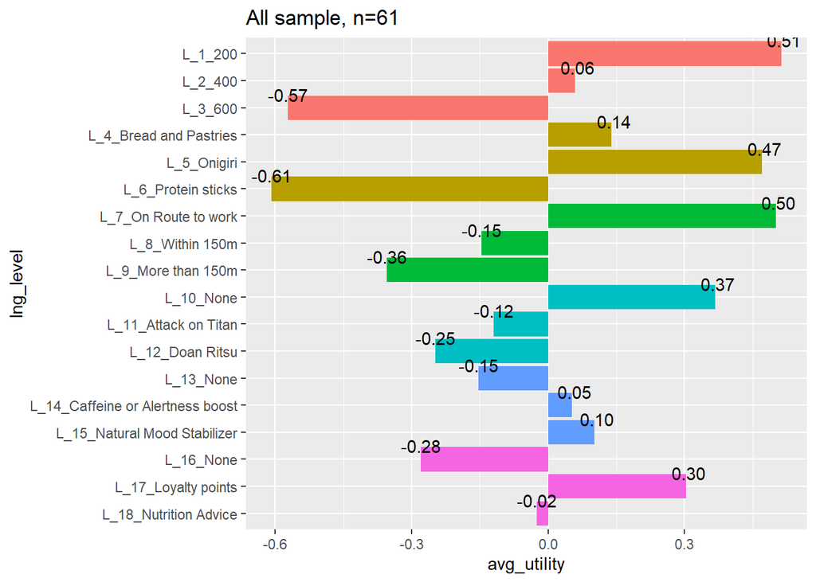

```r
ggplot(average_utility_df, aes(x=lng_level, y = avg_utility
                               ,fill = group_fct
))+
  geom_col() +
  coord_flip() +
  scale_x_discrete(limits = rev(levels(average_utility_df$lng_level))) +
  geom_text(aes(label = format(round(avg_utility, 2), nsmall = 2)), vjust = -0.5) +
  ggtitle(paste("All sample", length(brkfst$nickname), sep = ", n=")) +
  guides(fill="none")
```

To evaluate relative ordinal preference, we can sort descending by utility:

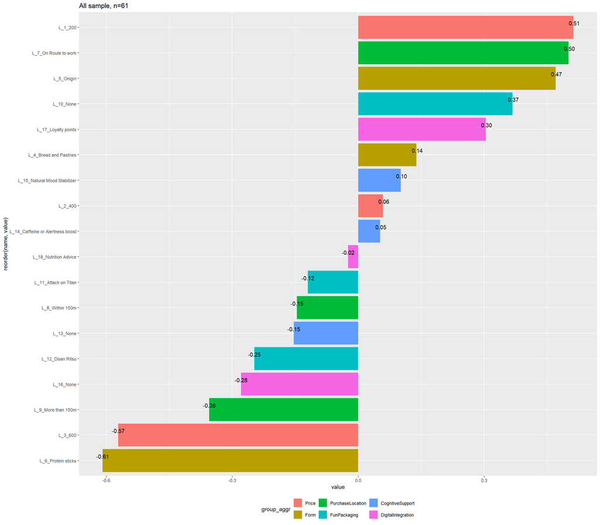

```r
## all sample parthworth utilities - sorted descending
plot_list <- list()
n_obs = length(brkfst_cmb$nickname)
iter = "All sample"

  brkfst_desc_slice <-  brkfst_cmb %>%
    mutate(item_col = iter) %>%
    group_by(item_col) %>%
    summarise_at(vars(L_1_200:`L_18_Nutrition Advice`),
                 mean , na.rm = TRUE) %>%
    pivot_longer(-item_col) %>%
    mutate(group_aggr =
             c("Price", "Price", "Price",
               "Form", "Form", "Form",
               "PurchaseLocation", "PurchaseLocation", "PurchaseLocation",
               "FunPackaging", "FunPackaging", "FunPackaging",
               "CognitiveSupport", "CognitiveSupport","CognitiveSupport",
               "DigitalIntegration", "DigitalIntegration", "DigitalIntegration"
             )) %>%
    mutate(group_aggr =
             factor(group_aggr, levels = c("Price", "Form", "PurchaseLocation",
                                           "FunPackaging", "CognitiveSupport", "DigitalIntegration"
             ))) %>%
    arrange(desc(value)) %>%
    ungroup

# kable(brkfst_desc_slice,
#       col.names = c("Observations", "Level","Utility", "Attribute"))
    ggplot(brkfst_desc_slice,
                           aes(x= reorder(name,value), y = value
                               ,fill = group_aggr
                           ))+
    geom_col() +
    coord_flip() +
    #scale_x_discrete(limits = rev(levels(average_utility_df$lng_level))) +
    geom_text(aes(label = format(round(value, 2), nsmall = 2)), vjust = -0.5) +
    ggtitle(paste(iter, n_obs, sep = ", n=")) +
    #guides(fill="none") +
    theme(legend.position="bottom")
```

## Computing importance

### Overall all sample

Going further, we plot the importance overall first.

```r
# Importance - # Overall all sample
kable(ca.importance(brkfst_part, attribute),
      col.names = "Attribute importance")
```

|  | Attribute importance |
| --- | --- |
| Price | 0.2424731 |
| Form | 0.2412452 |
| PurchaseLocation | 0.1914105 |
| FunPackaging | 0.1375659 |
| CognitiveSupport | 0.0569895 |
| DigitalIntegration | 0.1303157 |

Visualizing importance for the whole sample:

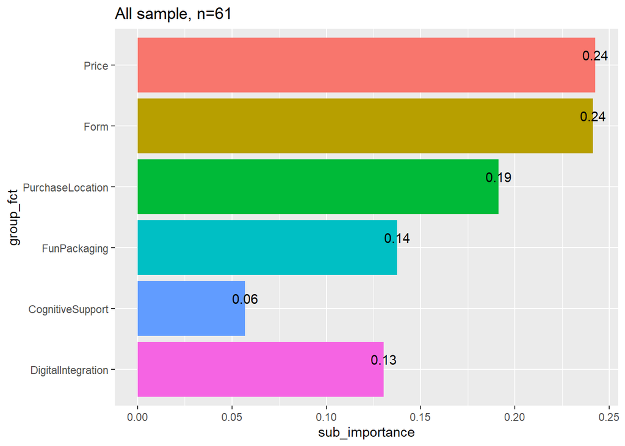

```r
## plot importance overall
sub_importance <-
  ca.importance(brkfst_part, attribute)

sub_importance_df <- data.frame(
  sub_importance = sub_importance,
  attribute_txt = names(sub_importance)
)
sub_importance_df <- sub_importance_df %>%
  mutate(group_fct = factor(attribute_txt, levels = c("Price", "Form", "PurchaseLocation",
                                                      "FunPackaging", "CognitiveSupport", "DigitalIntegration"
  )))

ggplot(sub_importance_df, aes(x=group_fct, y = sub_importance,
                              fill=group_fct)) +
  geom_col() +
  coord_flip() +
  scale_x_discrete(limits = rev(levels(sub_importance_df$group_fct))) +
  geom_text(aes(label = format(round(sub_importance, 2), nsmall = 2)), vjust = -0.5) +
  ggtitle(paste("All sample", length(brkfst$nickname), sep = ", n=")) +
  guides(fill="none")
```

It can be observed that for the whole sample, there are two variables that are very closely tied together: `Price` with 24% and `Form` with 24%. This suggests likely a trade-off between two different needs (low price and personal taste), which can be investigated through segmentation.

## Exploratory data analysis for subgroups

### Gender

We turn to subgroups. First, we explore the parthworth utility by gender:

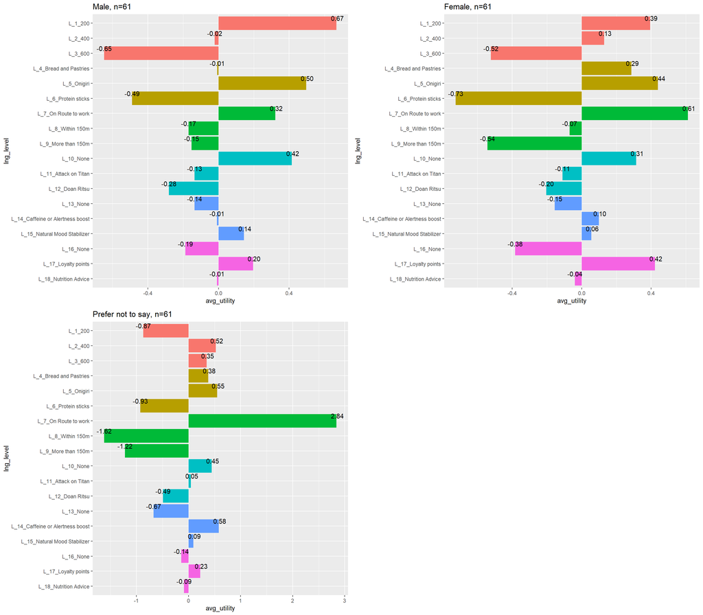

```r
#segmenting part-worth utilities
# =====
# gender

plot_list <- list()
var_by = brkfst$gender
attr_levels <- unique(var_by)

for (i in seq_along(attr_levels)) {

  iter = attr_levels[i]
  n_obs = length(brkfst_part[var_by == iter,1])

  average_utility <- colMeans(brkfst_part[var_by==iter,,drop=FALSE])
  average_utility_df <- data.frame(level = names(average_utility),
                                   avg_utility = average_utility)

  average_utility_df <-
    average_utility_df %>%
    filter(level != "intercept")

  average_utility_df <-
    average_utility_df %>%
    mutate(group =
             c("Price", "Price", "Price",
               "Form", "Form", "Form",
               "PurchaseLocation", "PurchaseLocation", "PurchaseLocation",
               "FunPackaging", "FunPackaging", "FunPackaging",
               "CognitiveSupport", "CognitiveSupport","CognitiveSupport",
               "DigitalIntegration", "DigitalIntegration", "DigitalIntegration"
             )) %>%
    mutate(level_fct = factor(level)) %>%
    mutate(rank = seq.int(1:length(average_utility_df$level))) %>%
    mutate(order_rnk = level, rank) %>%
    mutate(space_char = rep(c("L"), length(average_utility_df$level))) %>%
    unite("lng_level", c("space_char","rank","level"))

  average_utility_df <- average_utility_df %>%
    mutate(rank = seq.int(1:length(average_utility_df$level))) %>%
    mutate(lng_level = as.factor(lng_level)) %>%
    mutate(lng_level = fct_reorder(lng_level, rank )) %>%
    mutate(group_fct = factor(group, levels = c("Price", "Form", "PurchaseLocation",
                                                "FunPackaging", "CognitiveSupport", "DigitalIntegration"
    )))


  plot_list[[i]] <- ggplot(average_utility_df, aes(x=lng_level, y = avg_utility
                                                   ,fill = group_fct
  ))+
    geom_col() +
    coord_flip() +
    scale_x_discrete(limits = rev(levels(average_utility_df$lng_level))) +
    geom_text(aes(label = format(round(avg_utility, 2), nsmall = 2)), vjust = -0.5) +
    ggtitle(paste(iter, length(brkfst$nickname), sep = ", n=")) +
    guides(fill="none")
}
grid.arrange(grobs=plot_list,ncol=2)
```

To visualize relative importance by gender, we can sort descending:

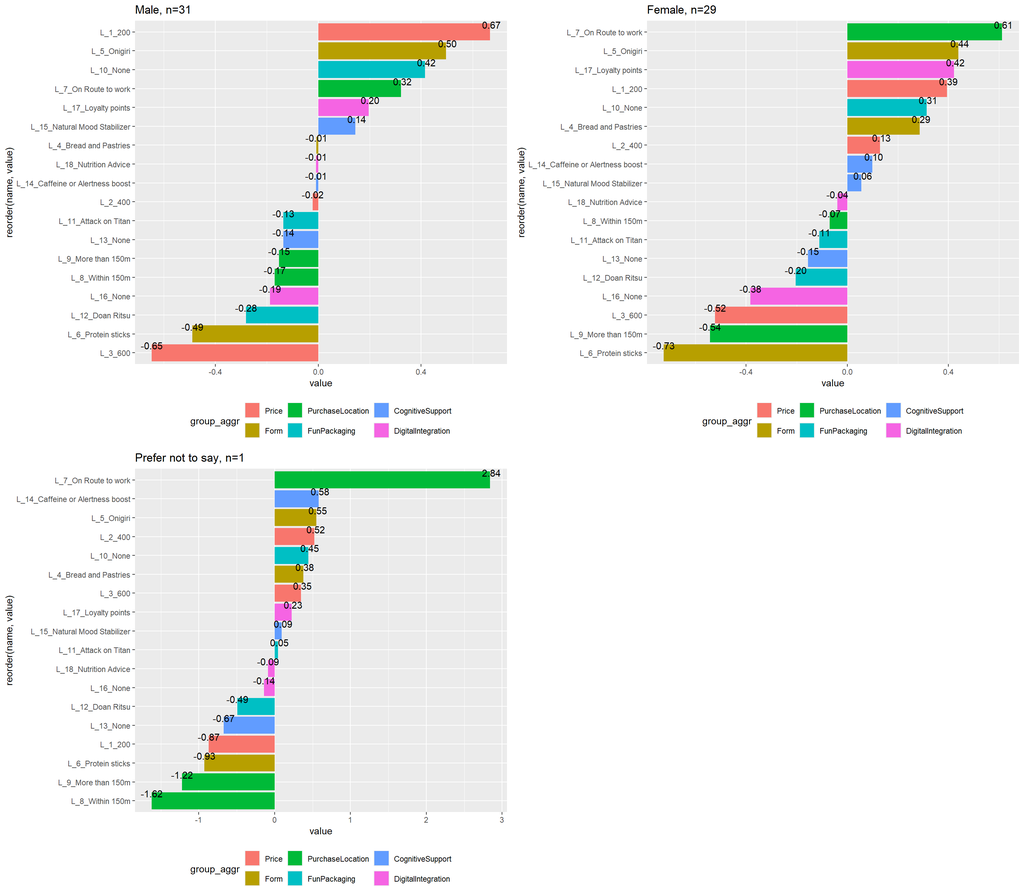

```r
# gender- sorted descending
plot_list <- list()
var_by = brkfst_cmb$gender
attr_levels <- unique(var_by)


for (i in seq_along(attr_levels)) {

  iter = attr_levels[i]
  n_obs = length(brkfst_cmb[var_by == iter,1])

  brkfst_desc_slice <-  brkfst_cmb[var_by == iter,] %>%
    mutate(item_col = iter) %>%
    group_by(item_col) %>%
    summarise_at(vars(L_1_200:`L_18_Nutrition Advice`),
                 mean , na.rm = TRUE) %>%
    pivot_longer(-item_col) %>%
    mutate(group_aggr =
             c("Price", "Price", "Price",
               "Form", "Form", "Form",
               "PurchaseLocation", "PurchaseLocation", "PurchaseLocation",
               "FunPackaging", "FunPackaging", "FunPackaging",
               "CognitiveSupport", "CognitiveSupport","CognitiveSupport",
               "DigitalIntegration", "DigitalIntegration", "DigitalIntegration"
             )) %>%
    mutate(group_aggr =
             factor(group_aggr, levels = c("Price", "Form", "PurchaseLocation",
                                           "FunPackaging", "CognitiveSupport", "DigitalIntegration"
             ))) %>%
    arrange(desc(value)) %>%
    ungroup

  #kable(brkfst_desc_slice)


  plot_list[[i]] <- ggplot(brkfst_desc_slice,
                           aes(x= reorder(name,value), y = value
                               ,fill = group_aggr
                           ))+
    geom_col() +
    coord_flip() +
    #scale_x_discrete(limits = rev(levels(average_utility_df$lng_level))) +
    geom_text(aes(label = format(round(value, 2), nsmall = 2)), vjust = -0.5) +
    ggtitle(paste(iter, n_obs, sep = ", n=")) +
    #guides(fill="none") +
    theme(legend.position="bottom")
}
grid.arrange(grobs=plot_list,ncol=2)
```

Subsequently, the importance of gender becomes:

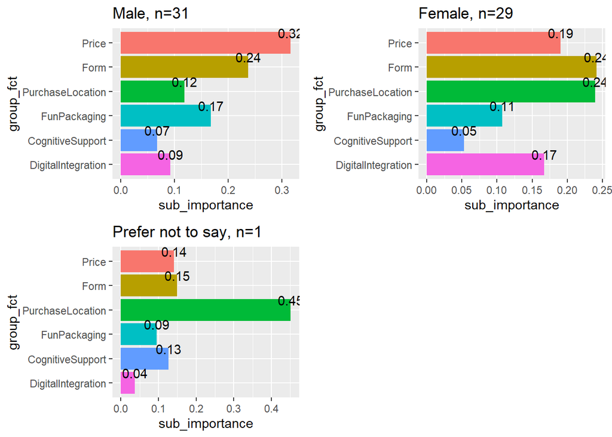

```r
#breakdown of importance by subcomponents
#### by gender
plot_list <- list()
var_by = brkfst$gender
attr_levels <- unique(var_by)

for (i in seq_along(attr_levels)) {

  iter = attr_levels[i]
  n_obs = length(brkfst_part[var_by == iter,1])

  sub_importance <-
    ca.importance(brkfst_part[var_by == iter,], attribute)

  sub_importance_df <- data.frame(
    sub_importance = sub_importance,
    attribute_txt = names(sub_importance)
  )
  sub_importance_df <- sub_importance_df %>%
    mutate(group_fct = factor(attribute_txt, levels = c("Price", "Form", "PurchaseLocation",
                                                        "FunPackaging", "CognitiveSupport", "DigitalIntegration"
    )))

  plot_list[[i]] <- ggplot(sub_importance_df, aes(x=group_fct, y = sub_importance,
                                                  fill=group_fct)) +
    geom_col() +
    coord_flip() +
    scale_x_discrete(limits = rev(levels(sub_importance_df$group_fct))) +
    geom_text(aes(label = format(round(sub_importance, 2), nsmall = 2)), vjust = -0.5) +
    ggtitle(paste(iter, n_obs, sep = ", n=")) +
    guides(fill="none")
}

grid.arrange(grobs=plot_list,ncol=2)
```

### Region

Turning to region, the partworth utilities:

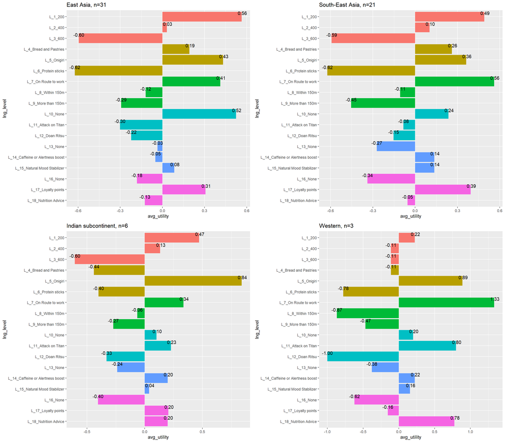

```r
#segmenting part-worth utilities
# =====
# region

plot_list <- list()
var_by = brkfst$region
attr_levels <- unique(var_by)

for (i in seq_along(attr_levels)) {

  iter = attr_levels[i]
  n_obs = length(brkfst_part[var_by == iter,1])

  average_utility <- colMeans(brkfst_part[var_by==iter,,drop=FALSE])
  average_utility_df <- data.frame(level = names(average_utility),
                                   avg_utility = average_utility)

  average_utility_df <-
    average_utility_df %>%
    filter(level != "intercept")

  average_utility_df <-
    average_utility_df %>%
    mutate(group =
             c("Price", "Price", "Price",
               "Form", "Form", "Form",
               "PurchaseLocation", "PurchaseLocation", "PurchaseLocation",
               "FunPackaging", "FunPackaging", "FunPackaging",
               "CognitiveSupport", "CognitiveSupport","CognitiveSupport",
               "DigitalIntegration", "DigitalIntegration", "DigitalIntegration"
             )) %>%
    mutate(level_fct = factor(level)) %>%
    mutate(rank = seq.int(1:length(average_utility_df$level))) %>%
    mutate(order_rnk = level, rank) %>%
    mutate(space_char = rep(c("L"), length(average_utility_df$level))) %>%
    unite("lng_level", c("space_char","rank","level"))

  average_utility_df <- average_utility_df %>%
    mutate(rank = seq.int(1:length(average_utility_df$level))) %>%
    mutate(lng_level = as.factor(lng_level)) %>%
    mutate(lng_level = fct_reorder(lng_level, rank )) %>%
    mutate(group_fct = factor(group, levels = c("Price", "Form", "PurchaseLocation",
                                                "FunPackaging", "CognitiveSupport", "DigitalIntegration"
    )))


  plot_list[[i]] <- ggplot(average_utility_df, aes(x=lng_level, y = avg_utility
                                                   ,fill = group_fct
  ))+
    geom_col() +
    coord_flip() +
    scale_x_discrete(limits = rev(levels(average_utility_df$lng_level))) +
    geom_text(aes(label = format(round(avg_utility, 2), nsmall = 2)), vjust = -0.5) +
    ggtitle(paste(iter, n_obs, sep = ", n=")) +
    guides(fill="none")
}
grid.arrange(grobs=plot_list,ncol=2)
```

To visualize relative importance by region, we can sort descending:

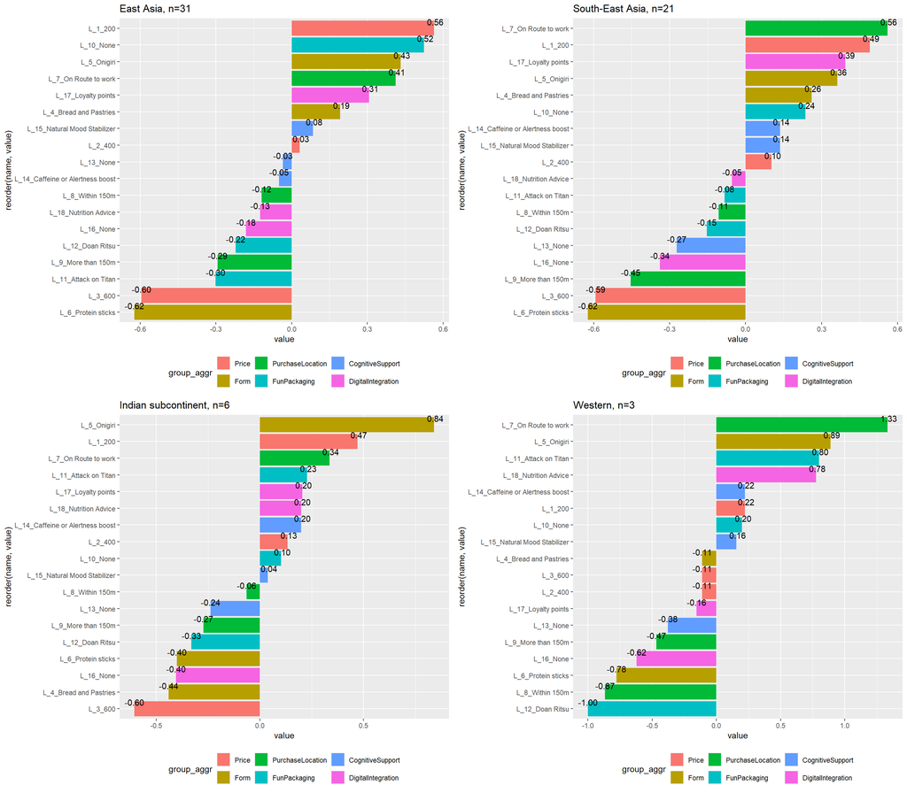

```r
# region - sorted descending
plot_list <- list()
var_by = brkfst_cmb$region
attr_levels <- unique(var_by)


for (i in seq_along(attr_levels)) {

  iter = attr_levels[i]
  n_obs = length(brkfst_cmb[var_by == iter,1])

  brkfst_desc_slice <-  brkfst_cmb[var_by == iter,] %>%
    mutate(item_col = iter) %>%
    group_by(item_col) %>%
    summarise_at(vars(L_1_200:`L_18_Nutrition Advice`),
                 mean , na.rm = TRUE) %>%
    pivot_longer(-item_col) %>%
    mutate(group_aggr =
             c("Price", "Price", "Price",
               "Form", "Form", "Form",
               "PurchaseLocation", "PurchaseLocation", "PurchaseLocation",
               "FunPackaging", "FunPackaging", "FunPackaging",
               "CognitiveSupport", "CognitiveSupport","CognitiveSupport",
               "DigitalIntegration", "DigitalIntegration", "DigitalIntegration"
             )) %>%
    mutate(group_aggr =
             factor(group_aggr, levels = c("Price", "Form", "PurchaseLocation",
                                           "FunPackaging", "CognitiveSupport", "DigitalIntegration"
             ))) %>%
    arrange(desc(value)) %>%
    ungroup

  #kable(brkfst_desc_slice)


  plot_list[[i]] <- ggplot(brkfst_desc_slice,
                           aes(x= reorder(name,value), y = value
                               ,fill = group_aggr
                           ))+
    geom_col() +
    coord_flip() +
    #scale_x_discrete(limits = rev(levels(average_utility_df$lng_level))) +
    geom_text(aes(label = format(round(value, 2), nsmall = 2)), vjust = -0.5) +
    ggtitle(paste(iter, n_obs, sep = ", n=")) +
    #guides(fill="none")
    theme(legend.position = "bottom")
}
grid.arrange(grobs=plot_list,ncol=2)
```

The importance of region is as follows.

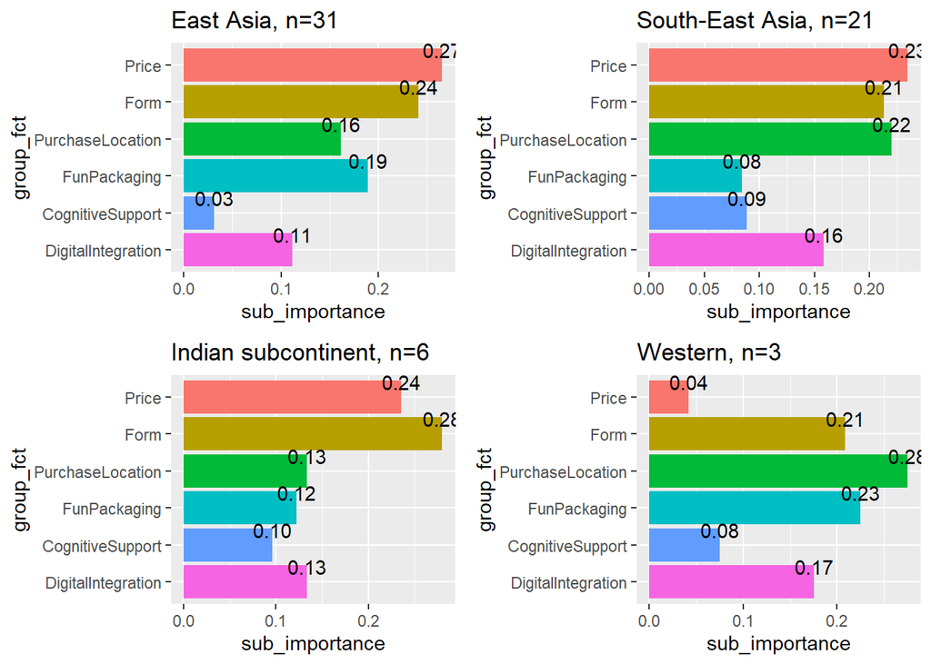

```r
#### by region
plot_list <- list()
var_by = brkfst$region
attr_levels <- unique(var_by)

for (i in seq_along(attr_levels)) {

  iter = attr_levels[i]
  n_obs = length(brkfst_part[var_by == iter,1])

  sub_importance <-
    ca.importance(brkfst_part[var_by == iter,], attribute)

  sub_importance_df <- data.frame(
    sub_importance = sub_importance,
    attribute_txt = names(sub_importance)
  )
  sub_importance_df <- sub_importance_df %>%
    mutate(group_fct = factor(attribute_txt, levels = c("Price", "Form", "PurchaseLocation",
                                                        "FunPackaging", "CognitiveSupport", "DigitalIntegration"
    )))

  plot_list[[i]] <- ggplot(sub_importance_df, aes(x=group_fct, y = sub_importance,
                                                  fill=group_fct)) +
    geom_col() +
    coord_flip() +
    scale_x_discrete(limits = rev(levels(sub_importance_df$group_fct))) +
    geom_text(aes(label = format(round(sub_importance, 2), nsmall = 2)), vjust = -0.5) +
    ggtitle(paste(iter, n_obs, sep = ", n=")) +
    guides(fill="none")
}

grid.arrange(grobs=plot_list,ncol=2)
```

### Age

Turning to Age, the parthworth utilities are:

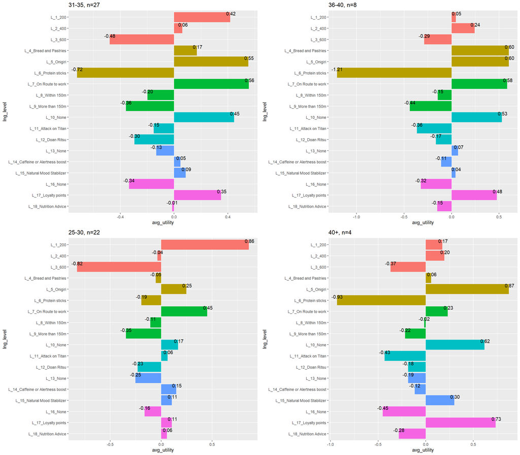

```r
#segmenting part-worth utilities
# =====
# age

plot_list <- list()
var_by = brkfst$age
attr_levels <- unique(var_by)

for (i in seq_along(attr_levels)) {

  iter = attr_levels[i]
  n_obs = length(brkfst_part[var_by == iter,1])

  average_utility <- colMeans(brkfst_part[var_by==iter,,drop=FALSE])
  average_utility_df <- data.frame(level = names(average_utility),
                                   avg_utility = average_utility)

  average_utility_df <-
    average_utility_df %>%
    filter(level != "intercept")

  average_utility_df <-
    average_utility_df %>%
    mutate(group =
             c("Price", "Price", "Price",
               "Form", "Form", "Form",
               "PurchaseLocation", "PurchaseLocation", "PurchaseLocation",
               "FunPackaging", "FunPackaging", "FunPackaging",
               "CognitiveSupport", "CognitiveSupport","CognitiveSupport",
               "DigitalIntegration", "DigitalIntegration", "DigitalIntegration"
             )) %>%
    mutate(level_fct = factor(level)) %>%
    mutate(rank = seq.int(1:length(average_utility_df$level))) %>%
    mutate(order_rnk = level, rank) %>%
    mutate(space_char = rep(c("L"), length(average_utility_df$level))) %>%
    unite("lng_level", c("space_char","rank","level"))

  average_utility_df <- average_utility_df %>%
    mutate(rank = seq.int(1:length(average_utility_df$level))) %>%
    mutate(lng_level = as.factor(lng_level)) %>%
    mutate(lng_level = fct_reorder(lng_level, rank )) %>%
    mutate(group_fct = factor(group, levels = c("Price", "Form", "PurchaseLocation",
                                                "FunPackaging", "CognitiveSupport", "DigitalIntegration"
    )))


  plot_list[[i]] <- ggplot(average_utility_df, aes(x=lng_level, y = avg_utility
                                                   ,fill = group_fct
  ))+
    geom_col() +
    coord_flip() +
    scale_x_discrete(limits = rev(levels(average_utility_df$lng_level))) +
    geom_text(aes(label = format(round(avg_utility, 2), nsmall = 2)), vjust = -0.5) +
    ggtitle(paste(iter, n_obs, sep = ", n=")) +
    guides(fill="none")
}
grid.arrange(grobs=plot_list,ncol=2)
```

To visualize relative importance by age, we can sort descending:

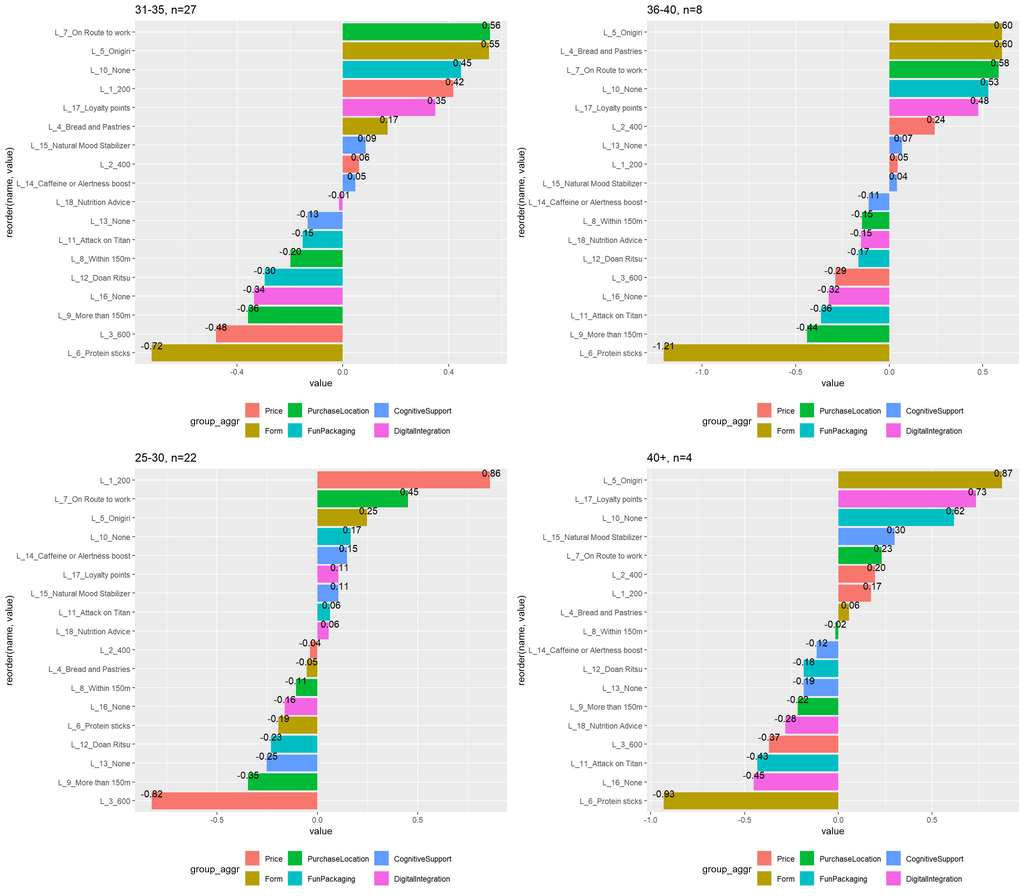

```r
# age - sorted descending
plot_list <- list()
var_by = brkfst_cmb$age
attr_levels <- unique(var_by)


for (i in seq_along(attr_levels)) {

  iter = attr_levels[i]
  n_obs = length(brkfst_cmb[var_by == iter,1])

  brkfst_desc_slice <-  brkfst_cmb[var_by == iter,] %>%
    mutate(item_col = iter) %>%
    group_by(item_col) %>%
    summarise_at(vars(L_1_200:`L_18_Nutrition Advice`),
                 mean , na.rm = TRUE) %>%
    pivot_longer(-item_col) %>%
    mutate(group_aggr =
             c("Price", "Price", "Price",
               "Form", "Form", "Form",
               "PurchaseLocation", "PurchaseLocation", "PurchaseLocation",
               "FunPackaging", "FunPackaging", "FunPackaging",
               "CognitiveSupport", "CognitiveSupport","CognitiveSupport",
               "DigitalIntegration", "DigitalIntegration", "DigitalIntegration"
             )) %>%
    mutate(group_aggr =
             factor(group_aggr, levels = c("Price", "Form", "PurchaseLocation",
                                           "FunPackaging", "CognitiveSupport", "DigitalIntegration"
             ))) %>%
    arrange(desc(value)) %>%
    ungroup

  #kable(brkfst_desc_slice)


  plot_list[[i]] <- ggplot(brkfst_desc_slice,
                           aes(x= reorder(name,value), y = value
                               ,fill = group_aggr
                           ))+
    geom_col() +
    coord_flip() +
    #scale_x_discrete(limits = rev(levels(average_utility_df$lng_level))) +
    geom_text(aes(label = format(round(value, 2), nsmall = 2)), vjust = -0.5) +
    ggtitle(paste(iter, n_obs, sep = ", n=")) +
    #guides(fill="none")
    theme(legend.position = "bottom")
}
grid.arrange(grobs=plot_list,ncol=2)
```

The importance of Age is as follows.

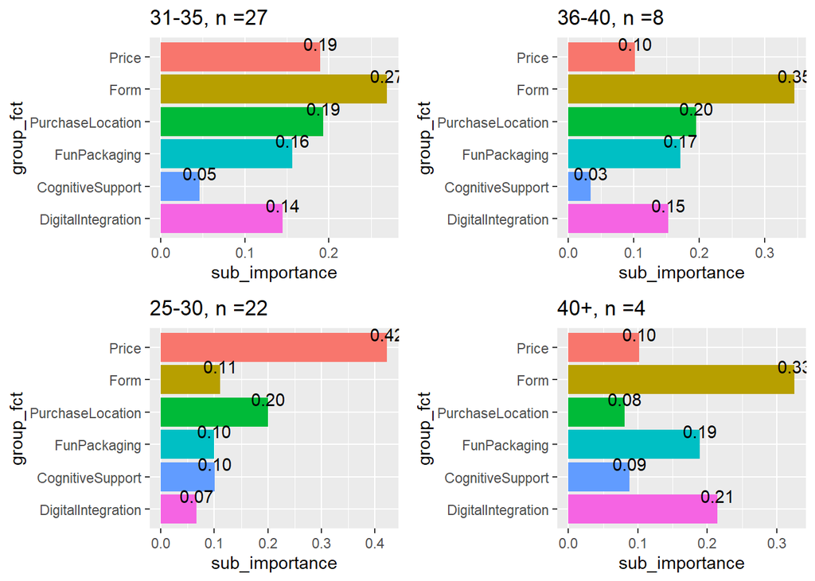

```r
# importance
#### by age
plot_list <- list()
var_by = brkfst$age
attr_levels <- unique(var_by)

for (i in seq_along(attr_levels)) {

  iter = attr_levels[i]
  n_obs = length(brkfst_part[var_by == iter,1])

  sub_importance <-
    ca.importance(brkfst_part[var_by == iter,], attribute)

  sub_importance_df <- data.frame(
    sub_importance = sub_importance,
    attribute_txt = names(sub_importance)
  )
  sub_importance_df <- sub_importance_df %>%
    mutate(group_fct = factor(attribute_txt, levels = c("Price", "Form", "PurchaseLocation",
                                                        "FunPackaging", "CognitiveSupport", "DigitalIntegration"
    )))

  plot_list[[i]] <- ggplot(sub_importance_df, aes(x=group_fct, y = sub_importance,
                                                  fill=group_fct)) +
    geom_col() +
    coord_flip() +
    scale_x_discrete(limits = rev(levels(sub_importance_df$group_fct))) +
    geom_text(aes(label = format(round(sub_importance, 2), nsmall = 2)), vjust = -0.5) +
    ggtitle(paste(iter, n_obs, sep = ", n =")) +
    guides(fill="none")
}

grid.arrange(grobs=plot_list,ncol=2)
```

### Civil status

Exploring by whether a person is leaving with their partner or not. The partworth utilities of Civil Status are:

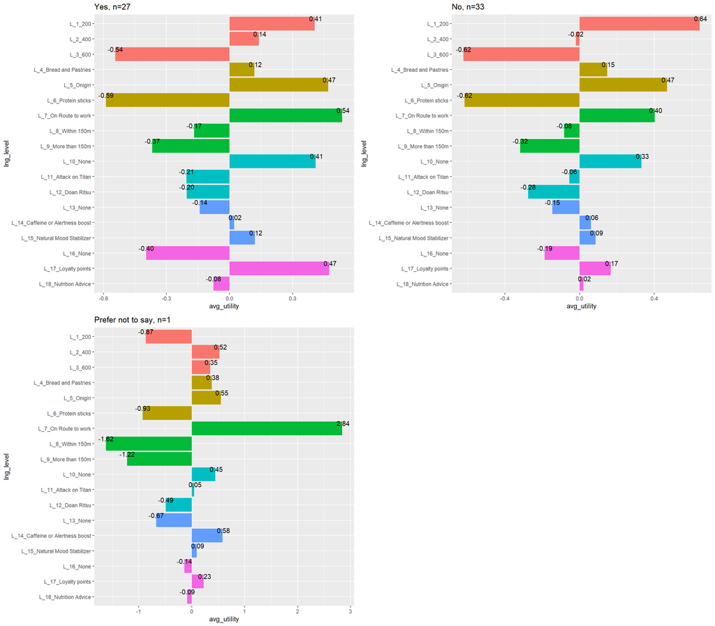

```r
#segmenting part-worth utilities
# =====
# living with partner

plot_list <- list()
var_by = brkfst$living_with_partner
attr_levels <- unique(var_by)

for (i in seq_along(attr_levels)) {

  iter = attr_levels[i]
  n_obs = length(brkfst_part[var_by == iter,1])

  average_utility <- colMeans(brkfst_part[var_by==iter,,drop=FALSE])
  average_utility_df <- data.frame(level = names(average_utility),
                                   avg_utility = average_utility)

  average_utility_df <-
    average_utility_df %>%
    filter(level != "intercept")

  average_utility_df <-
    average_utility_df %>%
    mutate(group =
             c("Price", "Price", "Price",
               "Form", "Form", "Form",
               "PurchaseLocation", "PurchaseLocation", "PurchaseLocation",
               "FunPackaging", "FunPackaging", "FunPackaging",
               "CognitiveSupport", "CognitiveSupport","CognitiveSupport",
               "DigitalIntegration", "DigitalIntegration", "DigitalIntegration"
             )) %>%
    mutate(level_fct = factor(level)) %>%
    mutate(rank = seq.int(1:length(average_utility_df$level))) %>%
    mutate(order_rnk = level, rank) %>%
    mutate(space_char = rep(c("L"), length(average_utility_df$level))) %>%
    unite("lng_level", c("space_char","rank","level"))

  average_utility_df <- average_utility_df %>%
    mutate(rank = seq.int(1:length(average_utility_df$level))) %>%
    mutate(lng_level = as.factor(lng_level)) %>%
    mutate(lng_level = fct_reorder(lng_level, rank )) %>%
    mutate(group_fct = factor(group, levels = c("Price", "Form", "PurchaseLocation",
                                                "FunPackaging", "CognitiveSupport", "DigitalIntegration"
    )))


  plot_list[[i]] <- ggplot(average_utility_df, aes(x=lng_level, y = avg_utility
                                                   ,fill = group_fct
  ))+
    geom_col() +
    coord_flip() +
    scale_x_discrete(limits = rev(levels(average_utility_df$lng_level))) +
    geom_text(aes(label = format(round(avg_utility, 2), nsmall = 2)), vjust = -0.5) +
    ggtitle(paste(iter, n_obs, sep = ", n=")) +
    guides(fill="none")
}
grid.arrange(grobs=plot_list,ncol=2)
```

To visualize relative importance by civil status, we can sort descending:

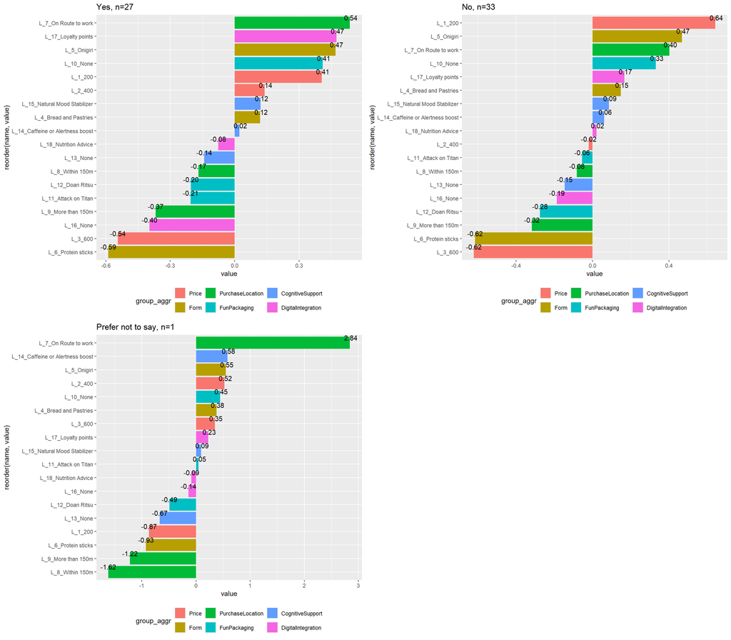

```r
# civil status - sorted descending
plot_list <- list()
var_by = brkfst_cmb$living_with_partner
attr_levels <- unique(var_by)


for (i in seq_along(attr_levels)) {

  iter = attr_levels[i]
  n_obs = length(brkfst_cmb[var_by == iter,1])

  brkfst_desc_slice <-  brkfst_cmb[var_by == iter,] %>%
    mutate(item_col = iter) %>%
    group_by(item_col) %>%
    summarise_at(vars(L_1_200:`L_18_Nutrition Advice`),
                 mean , na.rm = TRUE) %>%
    pivot_longer(-item_col) %>%
    mutate(group_aggr =
             c("Price", "Price", "Price",
               "Form", "Form", "Form",
               "PurchaseLocation", "PurchaseLocation", "PurchaseLocation",
               "FunPackaging", "FunPackaging", "FunPackaging",
               "CognitiveSupport", "CognitiveSupport","CognitiveSupport",
               "DigitalIntegration", "DigitalIntegration", "DigitalIntegration"
             )) %>%
    mutate(group_aggr =
             factor(group_aggr, levels = c("Price", "Form", "PurchaseLocation",
                                           "FunPackaging", "CognitiveSupport", "DigitalIntegration"
             ))) %>%
    arrange(desc(value)) %>%
    ungroup

  #kable(brkfst_desc_slice)


  plot_list[[i]] <- ggplot(brkfst_desc_slice,
                           aes(x= reorder(name,value), y = value
                               ,fill = group_aggr
                           ))+
    geom_col() +
    coord_flip() +
    #scale_x_discrete(limits = rev(levels(average_utility_df$lng_level))) +
    geom_text(aes(label = format(round(value, 2), nsmall = 2)), vjust = -0.5) +
    ggtitle(paste(iter, n_obs, sep = ", n=")) +
    #guides(fill="none")
    theme(legend.position = "bottom")
}
grid.arrange(grobs=plot_list,ncol=2)
```

The importance of Civil Status is:

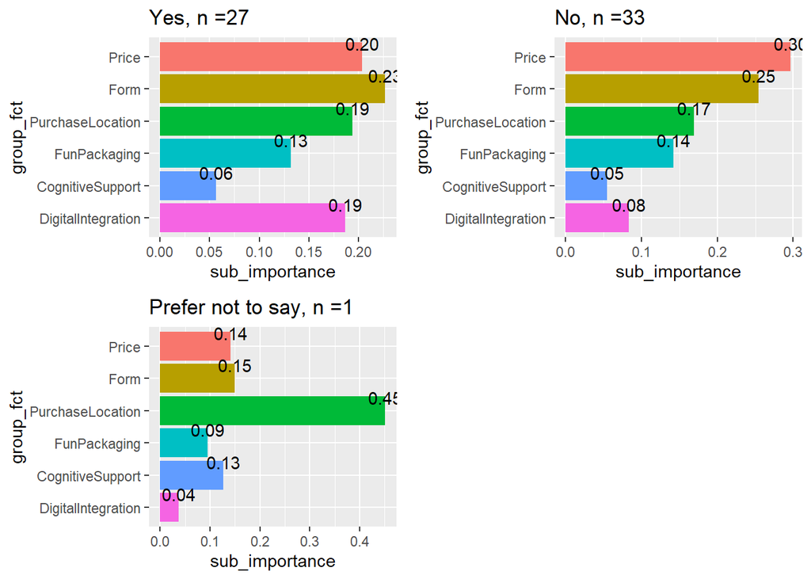

```r
# importance
#### by living with partner
plot_list <- list()
var_by = brkfst$living_with_partner
attr_levels <- unique(var_by)

for (i in seq_along(attr_levels)) {

  iter = attr_levels[i]
  n_obs = length(brkfst_part[var_by == iter,1])

  sub_importance <-
    ca.importance(brkfst_part[var_by == iter,], attribute)

  sub_importance_df <- data.frame(
    sub_importance = sub_importance,
    attribute_txt = names(sub_importance)
  )
  sub_importance_df <- sub_importance_df %>%
    mutate(group_fct = factor(attribute_txt, levels = c("Price", "Form", "PurchaseLocation",
                                                        "FunPackaging", "CognitiveSupport", "DigitalIntegration"
    )))

  plot_list[[i]] <- ggplot(sub_importance_df, aes(x=group_fct, y = sub_importance,
                                                  fill=group_fct)) +
    geom_col() +
    coord_flip() +
    scale_x_discrete(limits = rev(levels(sub_importance_df$group_fct))) +
    geom_text(aes(label = format(round(sub_importance, 2), nsmall = 2)), vjust = -0.5) +
    ggtitle(paste(iter, n_obs, sep = ", n =")) +
    guides(fill="none")
}

grid.arrange(grobs=plot_list,ncol=2)
```

### Expected Salary

Reflecting career ladder status and aspirations. The partworth utilities are:

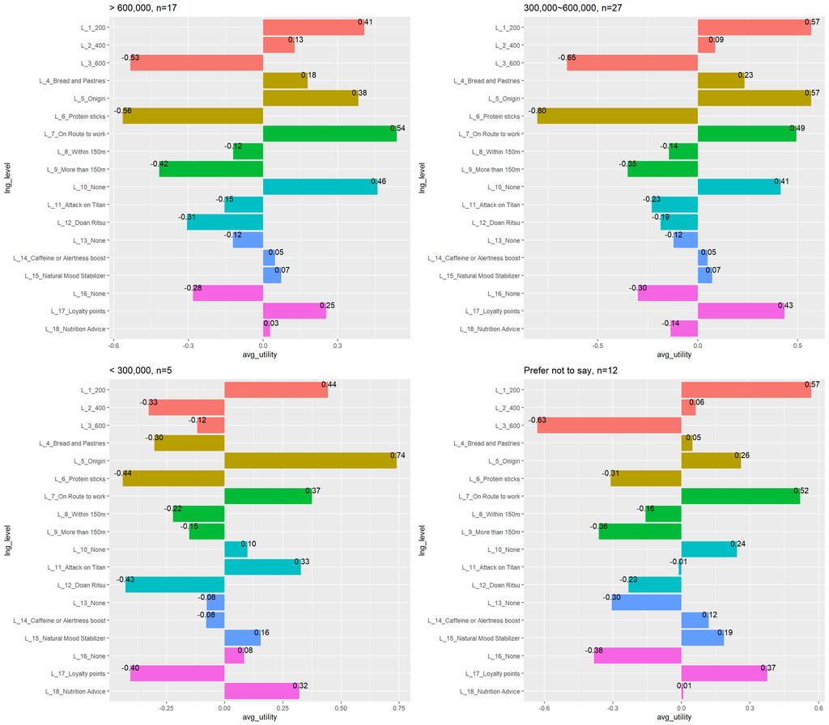

```r
#segmenting part-worth utilities
# =====
# living with partner

plot_list <- list()
var_by = brkfst$expected_salary
attr_levels <- unique(var_by)

for (i in seq_along(attr_levels)) {

  iter = attr_levels[i]
  n_obs = length(brkfst_part[var_by == iter,1])

  average_utility <- colMeans(brkfst_part[var_by==iter,,drop=FALSE])
  average_utility_df <- data.frame(level = names(average_utility),
                                   avg_utility = average_utility)

  average_utility_df <-
    average_utility_df %>%
    filter(level != "intercept")

  average_utility_df <-
    average_utility_df %>%
    mutate(group =
             c("Price", "Price", "Price",
               "Form", "Form", "Form",
               "PurchaseLocation", "PurchaseLocation", "PurchaseLocation",
               "FunPackaging", "FunPackaging", "FunPackaging",
               "CognitiveSupport", "CognitiveSupport","CognitiveSupport",
               "DigitalIntegration", "DigitalIntegration", "DigitalIntegration"
             )) %>%
    mutate(level_fct = factor(level)) %>%
    mutate(rank = seq.int(1:length(average_utility_df$level))) %>%
    mutate(order_rnk = level, rank) %>%
    mutate(space_char = rep(c("L"), length(average_utility_df$level))) %>%
    unite("lng_level", c("space_char","rank","level"))

  average_utility_df <- average_utility_df %>%
    mutate(rank = seq.int(1:length(average_utility_df$level))) %>%
    mutate(lng_level = as.factor(lng_level)) %>%
    mutate(lng_level = fct_reorder(lng_level, rank )) %>%
    mutate(group_fct = factor(group, levels = c("Price", "Form", "PurchaseLocation",
                                                "FunPackaging", "CognitiveSupport", "DigitalIntegration"
    )))


  plot_list[[i]] <- ggplot(average_utility_df, aes(x=lng_level, y = avg_utility
                                                   ,fill = group_fct
  ))+
    geom_col() +
    coord_flip() +
    scale_x_discrete(limits = rev(levels(average_utility_df$lng_level))) +
    geom_text(aes(label = format(round(avg_utility, 2), nsmall = 2)), vjust = -0.5) +
    ggtitle(paste(iter, n_obs, sep = ", n=")) +
    guides(fill="none")
}
grid.arrange(grobs=plot_list,ncol=2)
```

To visualize relative importance by expected salary, we can sort descending:

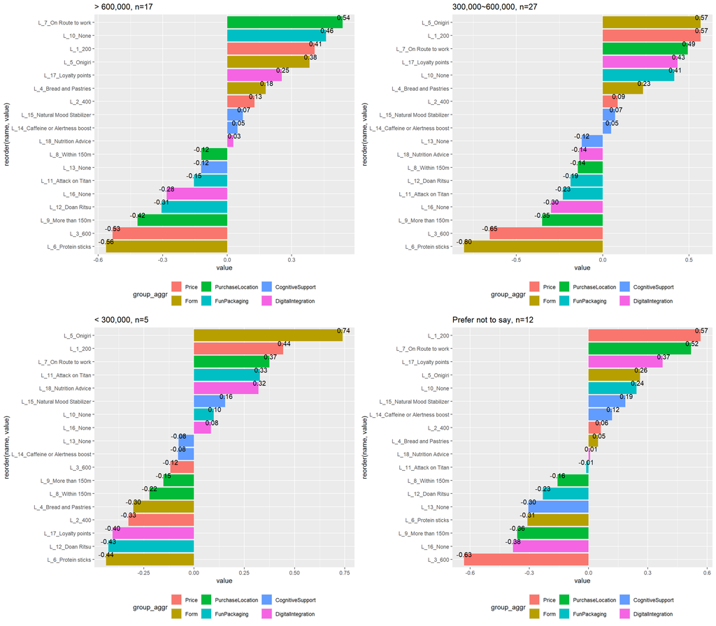

```r
# expected salary - sorted descending
plot_list <- list()
var_by = brkfst_cmb$expected_salary
attr_levels <- unique(var_by)


for (i in seq_along(attr_levels)) {

  iter = attr_levels[i]
  n_obs = length(brkfst_cmb[var_by == iter,1])

  brkfst_desc_slice <-  brkfst_cmb[var_by == iter,] %>%
    mutate(item_col = iter) %>%
    group_by(item_col) %>%
    summarise_at(vars(L_1_200:`L_18_Nutrition Advice`),
                 mean , na.rm = TRUE) %>%
    pivot_longer(-item_col) %>%
    mutate(group_aggr =
             c("Price", "Price", "Price",
               "Form", "Form", "Form",
               "PurchaseLocation", "PurchaseLocation", "PurchaseLocation",
               "FunPackaging", "FunPackaging", "FunPackaging",
               "CognitiveSupport", "CognitiveSupport","CognitiveSupport",
               "DigitalIntegration", "DigitalIntegration", "DigitalIntegration"
             )) %>%
    mutate(group_aggr =
             factor(group_aggr, levels = c("Price", "Form", "PurchaseLocation",
                                           "FunPackaging", "CognitiveSupport", "DigitalIntegration"
             ))) %>%
    arrange(desc(value)) %>%
    ungroup

  #kable(brkfst_desc_slice)


  plot_list[[i]] <- ggplot(brkfst_desc_slice,
                           aes(x= reorder(name,value), y = value
                               ,fill = group_aggr
                           ))+
    geom_col() +
    coord_flip() +
    #scale_x_discrete(limits = rev(levels(average_utility_df$lng_level))) +
    geom_text(aes(label = format(round(value, 2), nsmall = 2)), vjust = -0.5) +
    ggtitle(paste(iter, n_obs, sep = ", n=")) +
    #guides(fill="none")
    theme(legend.position = "bottom")
}
grid.arrange(grobs=plot_list,ncol=2)
```

The importance thus is:

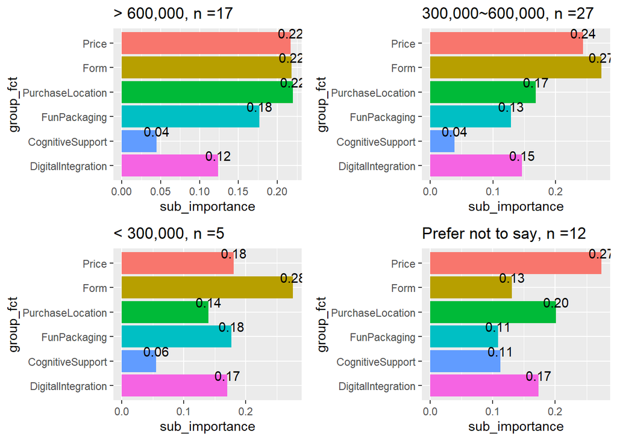

```r
#### by expected salary
plot_list <- list()
var_by = brkfst$expected_salary
attr_levels <- unique(var_by)

for (i in seq_along(attr_levels)) {

  iter = attr_levels[i]
  n_obs = length(brkfst_part[var_by == iter,1])

  sub_importance <-
    ca.importance(brkfst_part[var_by == iter,], attribute)

  sub_importance_df <- data.frame(
    sub_importance = sub_importance,
    attribute_txt = names(sub_importance)
  )
  sub_importance_df <- sub_importance_df %>%
    mutate(group_fct = factor(attribute_txt, levels = c("Price", "Form", "PurchaseLocation",
                                                        "FunPackaging", "CognitiveSupport", "DigitalIntegration"
    )))

  plot_list[[i]] <- ggplot(sub_importance_df, aes(x=group_fct, y = sub_importance,
                                                  fill=group_fct)) +
    geom_col() +
    coord_flip() +
    scale_x_discrete(limits = rev(levels(sub_importance_df$group_fct))) +
    geom_text(aes(label = format(round(sub_importance, 2), nsmall = 2)), vjust = -0.5) +
    ggtitle(paste(iter, n_obs, sep = ", n =")) +
    guides(fill="none")
}

grid.arrange(grobs=plot_list,ncol=2)
```

### Dietary restrictions

Exploring the impact of personal dietary restrictions. Partworth utilities are:

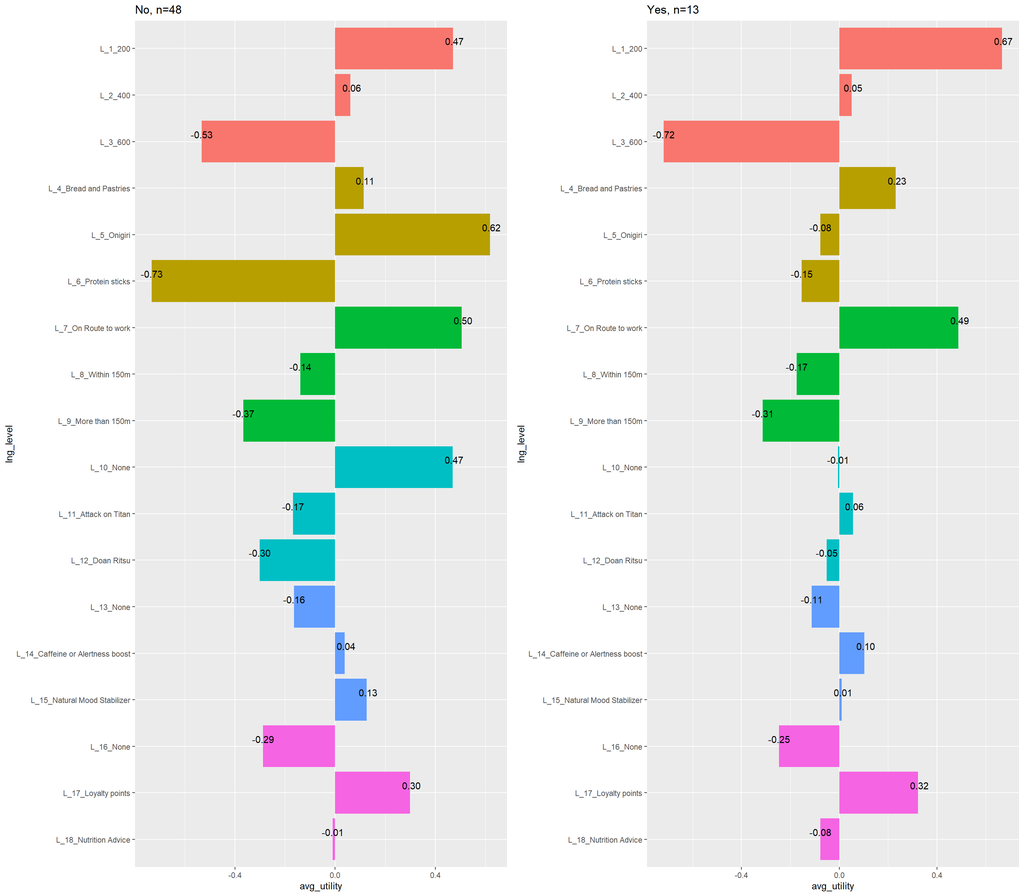

```r
#segmenting part-worth utilities
# =====
# dietary restriction

plot_list <- list()
var_by = brkfst$dietary_restrictions
attr_levels <- unique(var_by)

for (i in seq_along(attr_levels)) {

  iter = attr_levels[i]
  n_obs = length(brkfst_part[var_by == iter,1])

  average_utility <- colMeans(brkfst_part[var_by==iter,,drop=FALSE])
  average_utility_df <- data.frame(level = names(average_utility),
                                   avg_utility = average_utility)

  average_utility_df <-
    average_utility_df %>%
    filter(level != "intercept")

  average_utility_df <-
    average_utility_df %>%
    mutate(group =
             c("Price", "Price", "Price",
               "Form", "Form", "Form",
               "PurchaseLocation", "PurchaseLocation", "PurchaseLocation",
               "FunPackaging", "FunPackaging", "FunPackaging",
               "CognitiveSupport", "CognitiveSupport","CognitiveSupport",
               "DigitalIntegration", "DigitalIntegration", "DigitalIntegration"
             )) %>%
    mutate(level_fct = factor(level)) %>%
    mutate(rank = seq.int(1:length(average_utility_df$level))) %>%
    mutate(order_rnk = level, rank) %>%
    mutate(space_char = rep(c("L"), length(average_utility_df$level))) %>%
    unite("lng_level", c("space_char","rank","level"))

  average_utility_df <- average_utility_df %>%
    mutate(rank = seq.int(1:length(average_utility_df$level))) %>%
    mutate(lng_level = as.factor(lng_level)) %>%
    mutate(lng_level = fct_reorder(lng_level, rank )) %>%
    mutate(group_fct = factor(group, levels = c("Price", "Form", "PurchaseLocation",
                                                "FunPackaging", "CognitiveSupport", "DigitalIntegration"
    )))


  plot_list[[i]] <- ggplot(average_utility_df, aes(x=lng_level, y = avg_utility
                                                   ,fill = group_fct
  ))+
    geom_col() +
    coord_flip() +
    scale_x_discrete(limits = rev(levels(average_utility_df$lng_level))) +
    geom_text(aes(label = format(round(avg_utility, 2), nsmall = 2)), vjust = -0.5) +
    ggtitle(paste(iter, n_obs, sep = ", n=")) +
    guides(fill="none")
}
grid.arrange(grobs=plot_list,ncol=2)
```

To visualize relative importance by dietary restrictions, we can sort descending:

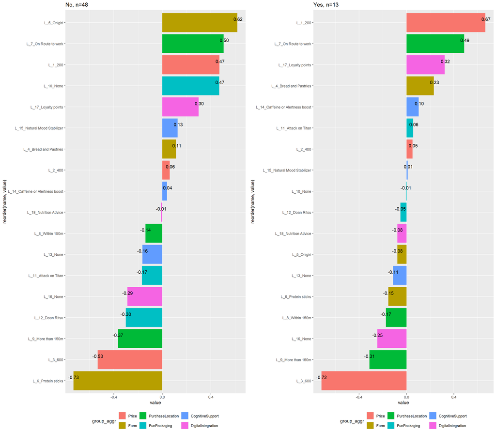

```r
# dietary restrictions - sorted descending
plot_list <- list()
var_by = brkfst_cmb$dietary_restrictions
attr_levels <- unique(var_by)


for (i in seq_along(attr_levels)) {

  iter = attr_levels[i]
  n_obs = length(brkfst_cmb[var_by == iter,1])

  brkfst_desc_slice <-  brkfst_cmb[var_by == iter,] %>%
    mutate(item_col = iter) %>%
    group_by(item_col) %>%
    summarise_at(vars(L_1_200:`L_18_Nutrition Advice`),
                 mean , na.rm = TRUE) %>%
    pivot_longer(-item_col) %>%
    mutate(group_aggr =
             c("Price", "Price", "Price",
               "Form", "Form", "Form",
               "PurchaseLocation", "PurchaseLocation", "PurchaseLocation",
               "FunPackaging", "FunPackaging", "FunPackaging",
               "CognitiveSupport", "CognitiveSupport","CognitiveSupport",
               "DigitalIntegration", "DigitalIntegration", "DigitalIntegration"
             )) %>%
    mutate(group_aggr =
             factor(group_aggr, levels = c("Price", "Form", "PurchaseLocation",
                                           "FunPackaging", "CognitiveSupport", "DigitalIntegration"
             ))) %>%
    arrange(desc(value)) %>%
    ungroup

  #kable(brkfst_desc_slice)


  plot_list[[i]] <- ggplot(brkfst_desc_slice,
                           aes(x= reorder(name,value), y = value
                               ,fill = group_aggr
                           ))+
    geom_col() +
    coord_flip() +
    #scale_x_discrete(limits = rev(levels(average_utility_df$lng_level))) +
    geom_text(aes(label = format(round(value, 2), nsmall = 2)), vjust = -0.5) +
    ggtitle(paste(iter, n_obs, sep = ", n=")) +
    #guides(fill="none")
    theme(legend.position = "bottom")
}
grid.arrange(grobs=plot_list,ncol=2)
```

The importance is:

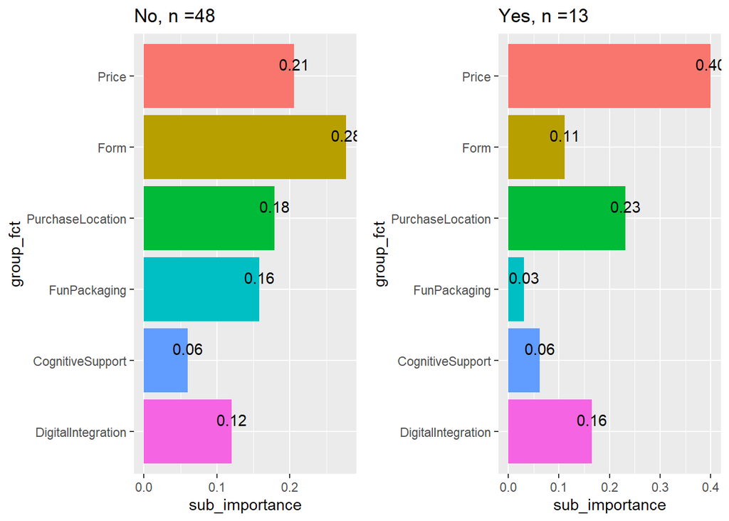

```r
## importance
#### by dietary restriction
plot_list <- list()
var_by = brkfst$dietary_restrictions
attr_levels <- unique(var_by)

for (i in seq_along(attr_levels)) {

  iter = attr_levels[i]
  n_obs = length(brkfst_part[var_by == iter,1])

  sub_importance <-
    ca.importance(brkfst_part[var_by == iter,], attribute)

  sub_importance_df <- data.frame(
    sub_importance = sub_importance,
    attribute_txt = names(sub_importance)
  )
  sub_importance_df <- sub_importance_df %>%
    mutate(group_fct = factor(attribute_txt, levels = c("Price", "Form", "PurchaseLocation",
                                                        "FunPackaging", "CognitiveSupport", "DigitalIntegration"
    )))

  plot_list[[i]] <- ggplot(sub_importance_df, aes(x=group_fct, y = sub_importance,
                                                  fill=group_fct)) +
    geom_col() +
    coord_flip() +
    scale_x_discrete(limits = rev(levels(sub_importance_df$group_fct))) +
    geom_text(aes(label = format(round(sub_importance, 2), nsmall = 2)), vjust = -0.5) +
    ggtitle(paste(iter, n_obs, sep = ", n =")) +
    guides(fill="none")
}

grid.arrange(grobs=plot_list,ncol=2)
```

### Work start

Breaking down by the time that the work day starts. The parthworth utilities:

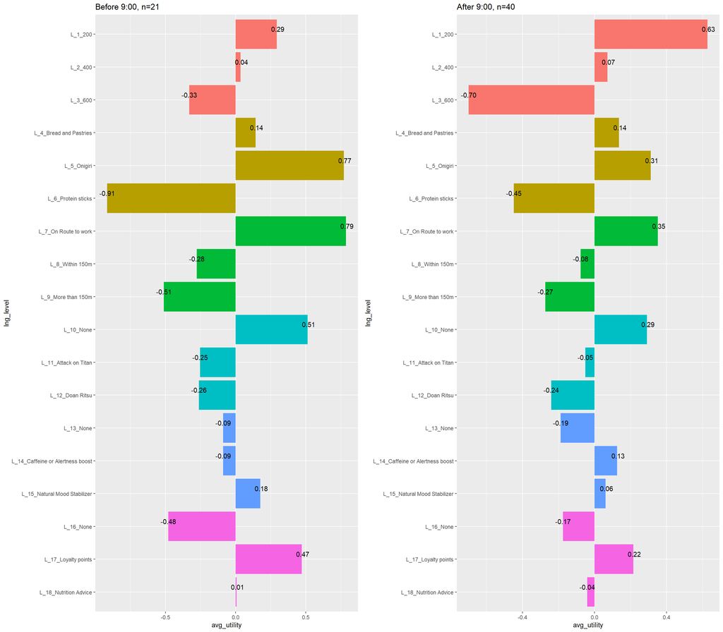

```r
#segmenting part-worth utilities
# =====
# work_start cut

plot_list <- list()
var_by = brkfst$work_start_cut
attr_levels <- unique(var_by)

for (i in seq_along(attr_levels)) {

  iter = attr_levels[i]
  n_obs = length(brkfst_part[var_by == iter,1])

  average_utility <- colMeans(brkfst_part[var_by==iter,,drop=FALSE])
  average_utility_df <- data.frame(level = names(average_utility),
                                   avg_utility = average_utility)

  average_utility_df <-
    average_utility_df %>%
    filter(level != "intercept")

  average_utility_df <-
    average_utility_df %>%
    mutate(group =
             c("Price", "Price", "Price",
               "Form", "Form", "Form",
               "PurchaseLocation", "PurchaseLocation", "PurchaseLocation",
               "FunPackaging", "FunPackaging", "FunPackaging",
               "CognitiveSupport", "CognitiveSupport","CognitiveSupport",
               "DigitalIntegration", "DigitalIntegration", "DigitalIntegration"
             )) %>%
    mutate(level_fct = factor(level)) %>%
    mutate(rank = seq.int(1:length(average_utility_df$level))) %>%
    mutate(order_rnk = level, rank) %>%
    mutate(space_char = rep(c("L"), length(average_utility_df$level))) %>%
    unite("lng_level", c("space_char","rank","level"))

  average_utility_df <- average_utility_df %>%
    mutate(rank = seq.int(1:length(average_utility_df$level))) %>%
    mutate(lng_level = as.factor(lng_level)) %>%
    mutate(lng_level = fct_reorder(lng_level, rank )) %>%
    mutate(group_fct = factor(group, levels = c("Price", "Form", "PurchaseLocation",
                                                "FunPackaging", "CognitiveSupport", "DigitalIntegration"
    )))


  plot_list[[i]] <- ggplot(average_utility_df, aes(x=lng_level, y = avg_utility
                                                   ,fill = group_fct
  ))+
    geom_col() +
    coord_flip() +
    scale_x_discrete(limits = rev(levels(average_utility_df$lng_level))) +
    geom_text(aes(label = format(round(avg_utility, 2), nsmall = 2)), vjust = -0.5) +
    ggtitle(paste(iter, n_obs, sep = ", n=")) +
    guides(fill="none")
}
grid.arrange(grobs=plot_list,ncol=2)
```

To visualize relative importance by work start time, we can sort descending:

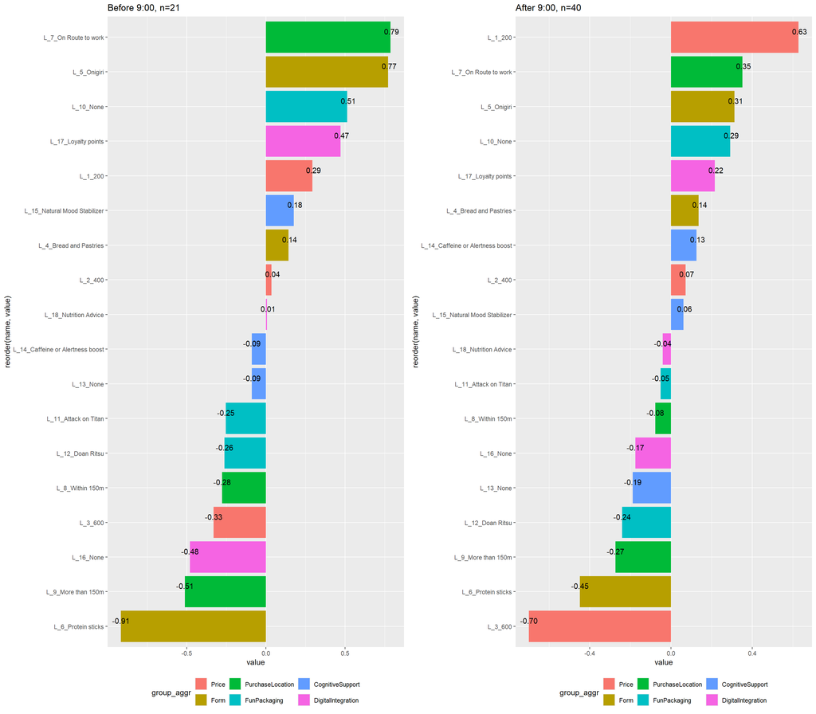

```r
# work start cut - sorted descending
plot_list <- list()
var_by = brkfst_cmb$work_start_cut
attr_levels <- unique(var_by)


for (i in seq_along(attr_levels)) {

  iter = attr_levels[i]
  n_obs = length(brkfst_cmb[var_by == iter,1])

  brkfst_desc_slice <-  brkfst_cmb[var_by == iter,] %>%
    mutate(item_col = iter) %>%
    group_by(item_col) %>%
    summarise_at(vars(L_1_200:`L_18_Nutrition Advice`),
                 mean , na.rm = TRUE) %>%
    pivot_longer(-item_col) %>%
    mutate(group_aggr =
             c("Price", "Price", "Price",
               "Form", "Form", "Form",
               "PurchaseLocation", "PurchaseLocation", "PurchaseLocation",
               "FunPackaging", "FunPackaging", "FunPackaging",
               "CognitiveSupport", "CognitiveSupport","CognitiveSupport",
               "DigitalIntegration", "DigitalIntegration", "DigitalIntegration"
             )) %>%
    mutate(group_aggr =
             factor(group_aggr, levels = c("Price", "Form", "PurchaseLocation",
                                           "FunPackaging", "CognitiveSupport", "DigitalIntegration"
             ))) %>%
    arrange(desc(value)) %>%
    ungroup

  #kable(brkfst_desc_slice)


  plot_list[[i]] <- ggplot(brkfst_desc_slice,
                           aes(x= reorder(name,value), y = value
                               ,fill = group_aggr
                           ))+
    geom_col() +
    coord_flip() +
    #scale_x_discrete(limits = rev(levels(average_utility_df$lng_level))) +
    geom_text(aes(label = format(round(value, 2), nsmall = 2)), vjust = -0.5) +
    ggtitle(paste(iter, n_obs, sep = ", n=")) +
    #guides(fill="none")
    theme(legend.position = "bottom")
}
grid.arrange(grobs=plot_list,ncol=2)
```

The work start importance:

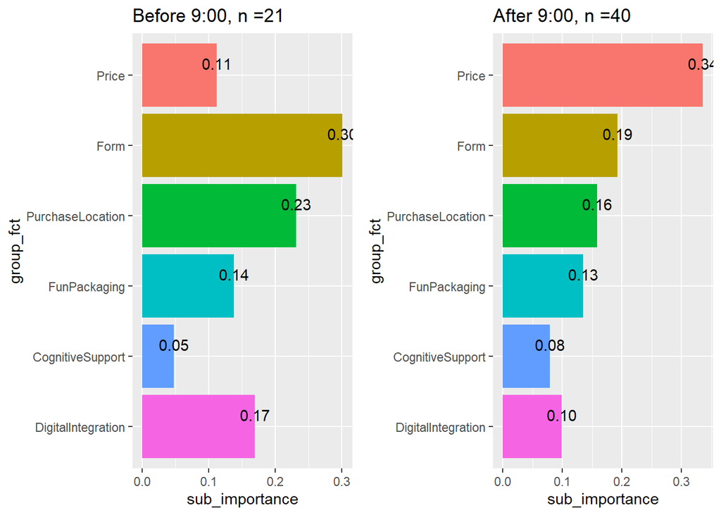

```r
#### by work start
plot_list <- list()
var_by = brkfst$work_start_cut
attr_levels <- unique(var_by)

for (i in seq_along(attr_levels)) {

  iter = attr_levels[i]
  n_obs = length(brkfst_part[var_by == iter,1])

  sub_importance <-
    ca.importance(brkfst_part[var_by == iter,], attribute)

  sub_importance_df <- data.frame(
    sub_importance = sub_importance,
    attribute_txt = names(sub_importance)
  )
  sub_importance_df <- sub_importance_df %>%
    mutate(group_fct = factor(attribute_txt, levels = c("Price", "Form", "PurchaseLocation",
                                                        "FunPackaging", "CognitiveSupport", "DigitalIntegration"
    )))

  plot_list[[i]] <- ggplot(sub_importance_df, aes(x=group_fct, y = sub_importance,
                                                  fill=group_fct)) +
    geom_col() +
    coord_flip() +
    scale_x_discrete(limits = rev(levels(sub_importance_df$group_fct))) +
    geom_text(aes(label = format(round(sub_importance, 2), nsmall = 2)), vjust = -0.5) +
    ggtitle(paste(iter, n_obs, sep = ", n =")) +
    guides(fill="none")
}

grid.arrange(grobs=plot_list,ncol=2)
```

### Exercise frequency

The number of times a person exercises per week. Partworth utilities:

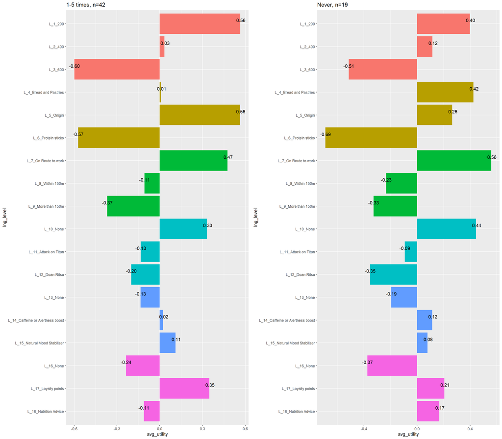

```r
#segmenting part-worth utilities
# =====
# exercise per week cut

plot_list <- list()
var_by = brkfst$exercise_per_week_cut
attr_levels <- unique(var_by)

for (i in seq_along(attr_levels)) {

  iter = attr_levels[i]
  n_obs = length(brkfst_part[var_by == iter,1])

  average_utility <- colMeans(brkfst_part[var_by==iter,,drop=FALSE])
  average_utility_df <- data.frame(level = names(average_utility),
                                   avg_utility = average_utility)

  average_utility_df <-
    average_utility_df %>%
    filter(level != "intercept")

  average_utility_df <-
    average_utility_df %>%
    mutate(group =
             c("Price", "Price", "Price",
               "Form", "Form", "Form",
               "PurchaseLocation", "PurchaseLocation", "PurchaseLocation",
               "FunPackaging", "FunPackaging", "FunPackaging",
               "CognitiveSupport", "CognitiveSupport","CognitiveSupport",
               "DigitalIntegration", "DigitalIntegration", "DigitalIntegration"
             )) %>%
    mutate(level_fct = factor(level)) %>%
    mutate(rank = seq.int(1:length(average_utility_df$level))) %>%
    mutate(order_rnk = level, rank) %>%
    mutate(space_char = rep(c("L"), length(average_utility_df$level))) %>%
    unite("lng_level", c("space_char","rank","level"))

  average_utility_df <- average_utility_df %>%
    mutate(rank = seq.int(1:length(average_utility_df$level))) %>%
    mutate(lng_level = as.factor(lng_level)) %>%
    mutate(lng_level = fct_reorder(lng_level, rank )) %>%
    mutate(group_fct = factor(group, levels = c("Price", "Form", "PurchaseLocation",
                                                "FunPackaging", "CognitiveSupport", "DigitalIntegration"
    )))


  plot_list[[i]] <- ggplot(average_utility_df, aes(x=lng_level, y = avg_utility
                                                   ,fill = group_fct
  ))+
    geom_col() +
    coord_flip() +
    scale_x_discrete(limits = rev(levels(average_utility_df$lng_level))) +
    geom_text(aes(label = format(round(avg_utility, 2), nsmall = 2)), vjust = -0.5) +
    ggtitle(paste(iter, n_obs, sep = ", n=")) +
    guides(fill="none")
}
grid.arrange(grobs=plot_list,ncol=2)
```

To visualize relative importance by exercise frequency, we can sort descending:

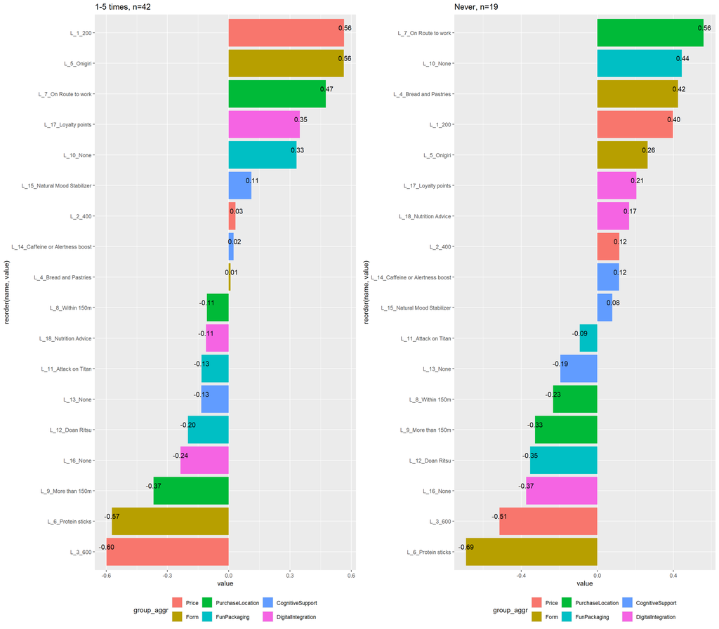

```r
# exercise frequency - sorted descending
plot_list <- list()
var_by = brkfst_cmb$exercise_per_week_cut
attr_levels <- unique(var_by)


for (i in seq_along(attr_levels)) {

  iter = attr_levels[i]
  n_obs = length(brkfst_cmb[var_by == iter,1])

  brkfst_desc_slice <-  brkfst_cmb[var_by == iter,] %>%
    mutate(item_col = iter) %>%
    group_by(item_col) %>%
    summarise_at(vars(L_1_200:`L_18_Nutrition Advice`),
                 mean , na.rm = TRUE) %>%
    pivot_longer(-item_col) %>%
    mutate(group_aggr =
             c("Price", "Price", "Price",
               "Form", "Form", "Form",
               "PurchaseLocation", "PurchaseLocation", "PurchaseLocation",
               "FunPackaging", "FunPackaging", "FunPackaging",
               "CognitiveSupport", "CognitiveSupport","CognitiveSupport",
               "DigitalIntegration", "DigitalIntegration", "DigitalIntegration"
             )) %>%
    mutate(group_aggr =
             factor(group_aggr, levels = c("Price", "Form", "PurchaseLocation",
                                           "FunPackaging", "CognitiveSupport", "DigitalIntegration"
             ))) %>%
    arrange(desc(value)) %>%
    ungroup

  #kable(brkfst_desc_slice)


  plot_list[[i]] <- ggplot(brkfst_desc_slice,
                           aes(x= reorder(name,value), y = value
                               ,fill = group_aggr
                           ))+
    geom_col() +
    coord_flip() +
    #scale_x_discrete(limits = rev(levels(average_utility_df$lng_level))) +
    geom_text(aes(label = format(round(value, 2), nsmall = 2)), vjust = -0.5) +
    ggtitle(paste(iter, n_obs, sep = ", n=")) +
    #guides(fill="none")
    theme(legend.position = "bottom")
}
grid.arrange(grobs=plot_list,ncol=2)
```

The importance is:

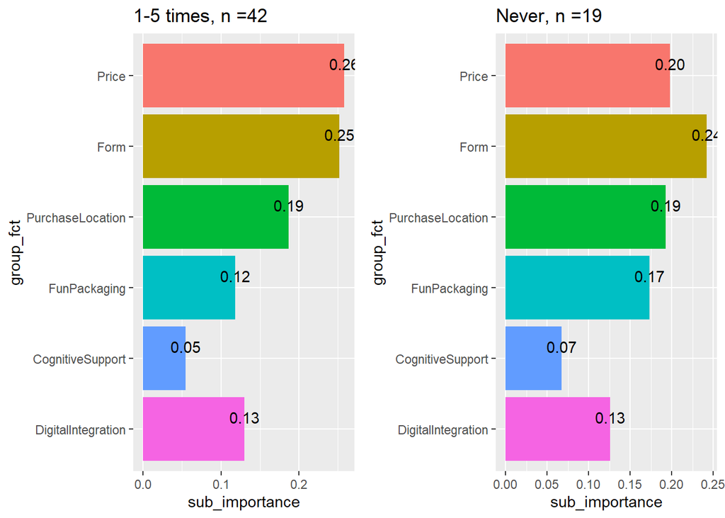

```r
#### by exercise per week
plot_list <- list()
var_by = brkfst$exercise_per_week_cut
attr_levels <- unique(var_by)

for (i in seq_along(attr_levels)) {

  iter = attr_levels[i]
  n_obs = length(brkfst_part[var_by == iter,1])

  sub_importance <-
    ca.importance(brkfst_part[var_by == iter,], attribute)

  sub_importance_df <- data.frame(
    sub_importance = sub_importance,
    attribute_txt = names(sub_importance)
  )
  sub_importance_df <- sub_importance_df %>%
    mutate(group_fct = factor(attribute_txt, levels = c("Price", "Form", "PurchaseLocation",
                                                        "FunPackaging", "CognitiveSupport", "DigitalIntegration"
    )))

  plot_list[[i]] <- ggplot(sub_importance_df, aes(x=group_fct, y = sub_importance,
                                                  fill=group_fct)) +
    geom_col() +
    coord_flip() +
    scale_x_discrete(limits = rev(levels(sub_importance_df$group_fct))) +
    geom_text(aes(label = format(round(sub_importance, 2), nsmall = 2)), vjust = -0.5) +
    ggtitle(paste(iter, n_obs, sep = ", n =")) +
    guides(fill="none")
}

grid.arrange(grobs=plot_list,ncol=2)
```

### Alcohol consumption

How much a person’s love for drinking influences their breakfast preferences. The parthworth utilities:

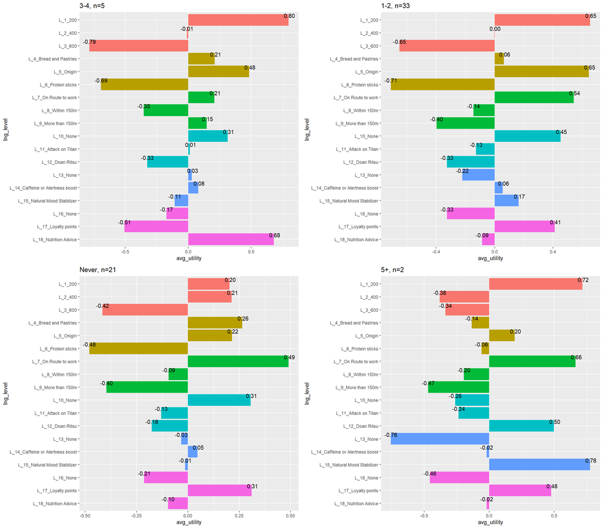

```r
#segmenting part-worth utilities
# =====
# alcohol per week
plot_list <- list()
var_by = brkfst$alcohol_per_week
attr_levels <- unique(var_by)

for (i in seq_along(attr_levels)) {

  iter = attr_levels[i]
  n_obs = length(brkfst_part[var_by == iter,1])

  average_utility <- colMeans(brkfst_part[var_by==iter,,drop=FALSE])
  average_utility_df <- data.frame(level = names(average_utility),
                                   avg_utility = average_utility)

  average_utility_df <-
    average_utility_df %>%
    filter(level != "intercept")

  average_utility_df <-
    average_utility_df %>%
    mutate(group =
             c("Price", "Price", "Price",
               "Form", "Form", "Form",
               "PurchaseLocation", "PurchaseLocation", "PurchaseLocation",
               "FunPackaging", "FunPackaging", "FunPackaging",
               "CognitiveSupport", "CognitiveSupport","CognitiveSupport",
               "DigitalIntegration", "DigitalIntegration", "DigitalIntegration"
             )) %>%
    mutate(level_fct = factor(level)) %>%
    mutate(rank = seq.int(1:length(average_utility_df$level))) %>%
    mutate(order_rnk = level, rank) %>%
    mutate(space_char = rep(c("L"), length(average_utility_df$level))) %>%
    unite("lng_level", c("space_char","rank","level"))

  average_utility_df <- average_utility_df %>%
    mutate(rank = seq.int(1:length(average_utility_df$level))) %>%
    mutate(lng_level = as.factor(lng_level)) %>%
    mutate(lng_level = fct_reorder(lng_level, rank )) %>%
    mutate(group_fct = factor(group, levels = c("Price", "Form", "PurchaseLocation",
                                                "FunPackaging", "CognitiveSupport", "DigitalIntegration"
    )))


  plot_list[[i]] <- ggplot(average_utility_df, aes(x=lng_level, y = avg_utility
                                                   ,fill = group_fct
  ))+
    geom_col() +
    coord_flip() +
    scale_x_discrete(limits = rev(levels(average_utility_df$lng_level))) +
    geom_text(aes(label = format(round(avg_utility, 2), nsmall = 2)), vjust = -0.5) +
    ggtitle(paste(iter, n_obs, sep = ", n=")) +
    guides(fill="none")
}
grid.arrange(grobs=plot_list,ncol=2)
```

To visualize relative importance by alcohol consumption, we can sort descending:

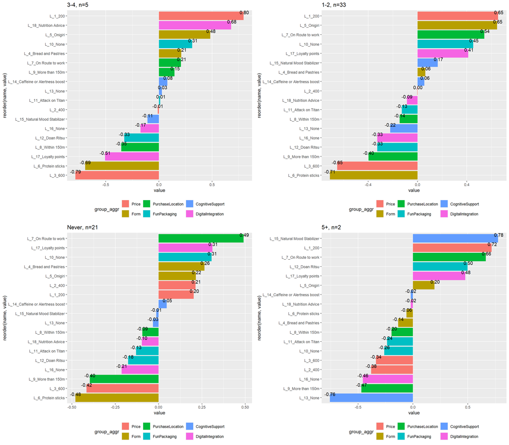

```r
# alcohol consumption - sorted descending
plot_list <- list()
var_by = brkfst_cmb$alcohol_per_week
attr_levels <- unique(var_by)


for (i in seq_along(attr_levels)) {

  iter = attr_levels[i]
  n_obs = length(brkfst_cmb[var_by == iter,1])

  brkfst_desc_slice <-  brkfst_cmb[var_by == iter,] %>%
    mutate(item_col = iter) %>%
    group_by(item_col) %>%
    summarise_at(vars(L_1_200:`L_18_Nutrition Advice`),
                 mean , na.rm = TRUE) %>%
    pivot_longer(-item_col) %>%
    mutate(group_aggr =
             c("Price", "Price", "Price",
               "Form", "Form", "Form",
               "PurchaseLocation", "PurchaseLocation", "PurchaseLocation",
               "FunPackaging", "FunPackaging", "FunPackaging",
               "CognitiveSupport", "CognitiveSupport","CognitiveSupport",
               "DigitalIntegration", "DigitalIntegration", "DigitalIntegration"
             )) %>%
    mutate(group_aggr =
             factor(group_aggr, levels = c("Price", "Form", "PurchaseLocation",
                                           "FunPackaging", "CognitiveSupport", "DigitalIntegration"
             ))) %>%
    arrange(desc(value)) %>%
    ungroup

  #kable(brkfst_desc_slice)


  plot_list[[i]] <- ggplot(brkfst_desc_slice,
                           aes(x= reorder(name,value), y = value
                               ,fill = group_aggr
                           ))+
    geom_col() +
    coord_flip() +
    #scale_x_discrete(limits = rev(levels(average_utility_df$lng_level))) +
    geom_text(aes(label = format(round(value, 2), nsmall = 2)), vjust = -0.5) +
    ggtitle(paste(iter, n_obs, sep = ", n=")) +
    #guides(fill="none")
    theme(legend.position = "bottom")
}
grid.arrange(grobs=plot_list,ncol=2)
```

The importance of alcohol consumption:

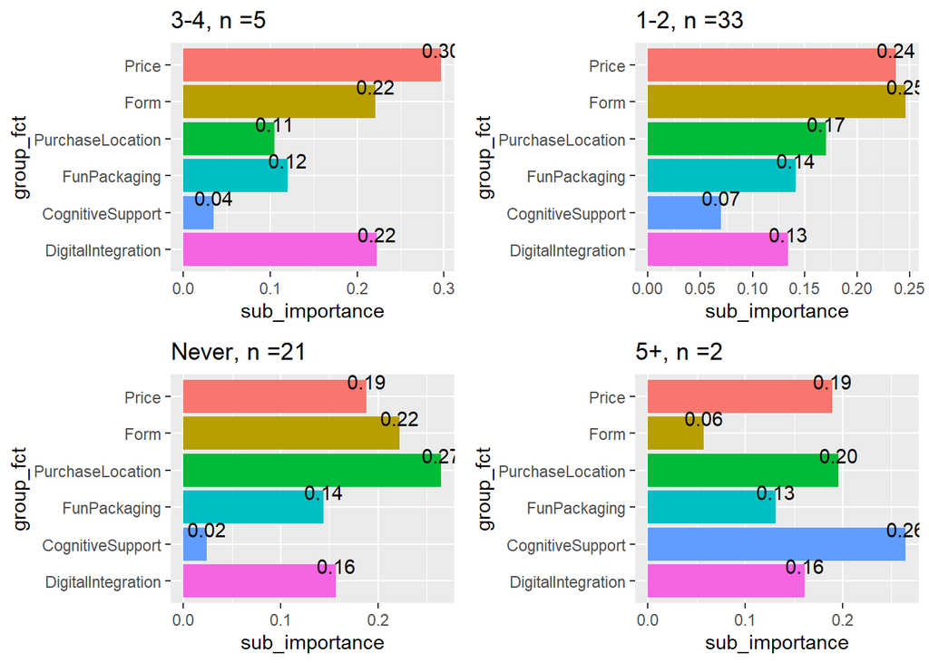

```r
#### by alcohol per week
plot_list <- list()
var_by = brkfst$alcohol_per_week
attr_levels <- unique(var_by)

for (i in seq_along(attr_levels)) {

  iter = attr_levels[i]
  n_obs = length(brkfst_part[var_by == iter,1])

  sub_importance <-
    ca.importance(brkfst_part[var_by == iter,], attribute)

  sub_importance_df <- data.frame(
    sub_importance = sub_importance,
    attribute_txt = names(sub_importance)
  )
  sub_importance_df <- sub_importance_df %>%
    mutate(group_fct = factor(attribute_txt, levels = c("Price", "Form", "PurchaseLocation",
                                                        "FunPackaging", "CognitiveSupport", "DigitalIntegration"
    )))

  plot_list[[i]] <- ggplot(sub_importance_df, aes(x=group_fct, y = sub_importance,
                                                  fill=group_fct)) +
    geom_col() +
    coord_flip() +
    scale_x_discrete(limits = rev(levels(sub_importance_df$group_fct))) +
    geom_text(aes(label = format(round(sub_importance, 2), nsmall = 2)), vjust = -0.5) +
    ggtitle(paste(iter, n_obs, sep = ", n =")) +
    guides(fill="none")
}

grid.arrange(grobs=plot_list,ncol=2)
```

## Segmentation

### Estimation and Interpretation

To gain insight into behavioral subgroups, we run a segmentation analysis. To decide the number of clusters, we first look at the silhouette plot.

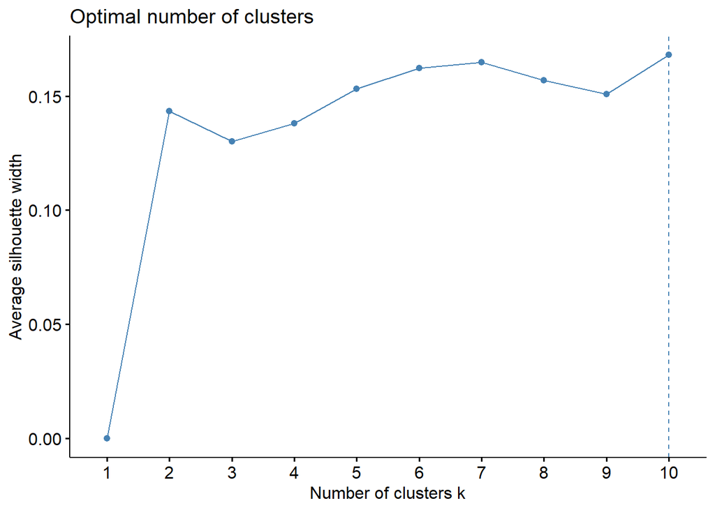

```r
# exclude intercept column
brkfst_part_sg <- data.frame(brkfst_part[,-1])
names(brkfst_part_sg)[10] <- c("No special packaging")
names(brkfst_part_sg)[13] <- c("No cognitive support")
names(brkfst_part_sg)[16] <- c("No digital integration")

# silhouette plot
fviz_nbclust(brkfst_part_sg, kmeans, method="silhouette")
```

Estimating four clusters:

```r
# estimating clusters
brkfst_sg_4 <- k.means(brkfst_part_sg, n.cluster=4)

# Cluster sizes
prop.table(brkfst_sg_4$size)
```

```
## [1] 0.36065574 0.27868852 0.26229508 0.09836066
```

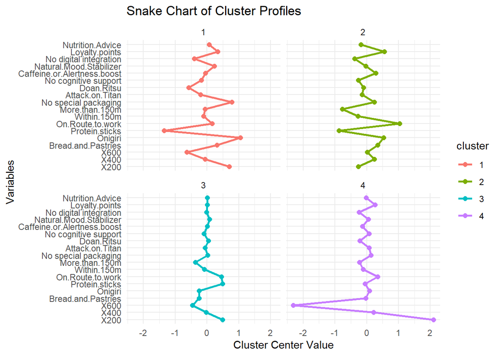

```r
# interpreting clusters
snake.ch2(brkfst_sg_4)
```